# Исследование объявлений о продаже квартир

В вашем распоряжении данные сервиса Яндекс.Недвижимость — архив объявлений о продаже квартир в Санкт-Петербурге и соседних населённых пунктах за несколько лет.

**Цель исследования** — установить параметры, которые определяют рыночную стоимость объектов недвижимости. Это позволит построить автоматизированную систему: она отследит аномалии и мошенническую деятельность.

По каждой квартире на продажу доступны два вида данных. Первые вписаны пользователем, вторые получены автоматически на основе картографических данных.

**Описание данных**

- `total_images` — число фотографий квартиры в объявлении
- `last_price` — цена на момент снятия с публикации
- `total_area` — площадь квартиры в квадратных метрах (м²)
- `first_day_exposition` — дата публикации
- `rooms` — число комнат
- `ceiling_height` — высота потолков (м)
- `floors_total` — всего этажей в доме
- `living_area` — жилая площадь в квадратных метрах (м²)
- `floor` — этаж
- `is_apartment` — апартаменты (булев тип)
- `studio` — квартира-студия (булев тип)
- `open_plan` — свободная планировка (булев тип)
- `kitchen_area` — площадь кухни в квадратных метрах (м²)
- `balcony` — число балконов
- `locality_name` — название населённого пункта
- `airports_nearest` — расстояние до ближайшего аэропорта в метрах (м)
- `cityCenters_nearest` — расстояние до центра города (м)
- `parks_around3000` — число парков в радиусе 3000 м
- `parks_nearest` — расстояние до ближайшего парка (м)
- `ponds_around3000` — число водоёмов в радиусе 3000 м
- `ponds_nearest` — расстояние до ближайшего водоёма (м)
- `days_exposition` — сколько дней было размещено объявление (от публикации до снятия).

## Обзор данных

```python
# Импортируем библиотеки
import pandas as pd
import numpy as np
import matplotlib.pyplot as plt
import math
import warnings
warnings.filterwarnings('ignore')
```

```python
# Сохраним данные в data
data = pd.read_csv('/datasets/real_estate_data.csv', sep='\t')
# Посмотри общую информацию о data
data.info()
data.sample(5)
```

```
<class 'pandas.core.frame.DataFrame'>
RangeIndex: 23699 entries, 0 to 23698
Data columns (total 22 columns):
 #   Column                Non-Null Count  Dtype
---  ------                --------------  -----
 0   total_images          23699 non-null  int64
 1   last_price            23699 non-null  float64
 2   total_area            23699 non-null  float64
 3   first_day_exposition  23699 non-null  object
 4   rooms                 23699 non-null  int64
 5   ceiling_height        14504 non-null  float64
 6   floors_total          23613 non-null  float64
 7   living_area           21796 non-null  float64
 8   floor                 23699 non-null  int64
 9   is_apartment          2775 non-null   object
 10  studio                23699 non-null  bool
 11  open_plan             23699 non-null  bool
 12  kitchen_area          21421 non-null  float64
 13  balcony               12180 non-null  float64
 14  locality_name         23650 non-null  object
 15  airports_nearest      18157 non-null  float64
 16  cityCenters_nearest   18180 non-null  float64
 17  parks_around3000      18181 non-null  float64
 18  parks_nearest         8079 non-null   float64
 19  ponds_around3000      18181 non-null  float64
 20  ponds_nearest         9110 non-null   float64
 21  days_exposition       20518 non-null  float64
dtypes: bool(2), float64(14), int64(3), object(3)
memory usage: 3.7+ MB
```

|  | total_images | last_price | total_area | first_day_exposition | rooms | ceiling_height | floors_total | living_area | floor | is_apartment | ... | kitchen_area | balcony | locality_name | airports_nearest | cityCenters_nearest | parks_around3000 | parks_nearest | ponds_around3000 | ponds_nearest | days_exposition |
| --- | --- | --- | --- | --- | --- | --- | --- | --- | --- | --- | --- | --- | --- | --- | --- | --- | --- | --- | --- | --- | --- |
| 218 | 11 | 4690000.0 | 35.0 | 2019-04-01T00:00:00 | 1 | 2.7 | 17.0 | 16.0 | 15 | False | ... | 9.8 | 1.0 | Санкт-Петербург | 36237.0 | 13151.0 | 0.0 | NaN | 0.0 | NaN | NaN |
| 18243 | 4 | 2350000.0 | 30.6 | 2017-11-09T00:00:00 | 1 | 2.5 | 5.0 | 17.3 | 2 | NaN | ... | 6.5 | NaN | посёлок Металлострой | 25758.0 | 27470.0 | 0.0 | NaN | 0.0 | NaN | 169.0 |
| 22778 | 0 | 4850000.0 | 40.0 | 2017-11-15T00:00:00 | 1 | NaN | 24.0 | 18.5 | 6 | NaN | ... | 9.0 | 2.0 | Санкт-Петербург | 7201.0 | 13417.0 | 1.0 | 1199.0 | 0.0 | NaN | 112.0 |
| 19723 | 18 | 13000000.0 | 120.0 | 2018-08-27T00:00:00 | 4 | NaN | 16.0 | 55.0 | 16 | NaN | ... | 30.0 | NaN | Санкт-Петербург | 42148.0 | 9380.0 | 0.0 | NaN | 0.0 | NaN | 67.0 |
| 20620 | 13 | 5190000.0 | 44.0 | 2018-03-02T00:00:00 | 1 | 3.0 | 15.0 | 20.1 | 8 | NaN | ... | 10.3 | 2.0 | Санкт-Петербург | 33531.0 | 12163.0 | 0.0 | NaN | 0.0 | NaN | 159.0 |

5 rows × 22 columns

```python
# Получим более подробную информацию о data
data.describe()
```

|  | total_images | last_price | total_area | rooms | ceiling_height | floors_total | living_area | floor | kitchen_area | balcony | airports_nearest | cityCenters_nearest | parks_around3000 | parks_nearest | ponds_around3000 | ponds_nearest | days_exposition |
| --- | --- | --- | --- | --- | --- | --- | --- | --- | --- | --- | --- | --- | --- | --- | --- | --- | --- |
| count | 23699.000000 | 2.369900e+04 | 23699.000000 | 23699.000000 | 14504.000000 | 23613.000000 | 21796.000000 | 23699.000000 | 21421.000000 | 12180.000000 | 18157.000000 | 18180.000000 | 18181.000000 | 8079.000000 | 18181.000000 | 9110.000000 | 20518.000000 |
| mean | 9.858475 | 6.541549e+06 | 60.348651 | 2.070636 | 2.771499 | 10.673824 | 34.457852 | 5.892358 | 10.569807 | 1.150082 | 28793.672193 | 14191.277833 | 0.611408 | 490.804555 | 0.770255 | 517.980900 | 180.888634 |
| std | 5.682529 | 1.088701e+07 | 35.654083 | 1.078405 | 1.261056 | 6.597173 | 22.030445 | 4.885249 | 5.905438 | 1.071300 | 12630.880622 | 8608.386210 | 0.802074 | 342.317995 | 0.938346 | 277.720643 | 219.727988 |
| min | 0.000000 | 1.219000e+04 | 12.000000 | 0.000000 | 1.000000 | 1.000000 | 2.000000 | 1.000000 | 1.300000 | 0.000000 | 0.000000 | 181.000000 | 0.000000 | 1.000000 | 0.000000 | 13.000000 | 1.000000 |
| 25% | 6.000000 | 3.400000e+06 | 40.000000 | 1.000000 | 2.520000 | 5.000000 | 18.600000 | 2.000000 | 7.000000 | 0.000000 | 18585.000000 | 9238.000000 | 0.000000 | 288.000000 | 0.000000 | 294.000000 | 45.000000 |
| 50% | 9.000000 | 4.650000e+06 | 52.000000 | 2.000000 | 2.650000 | 9.000000 | 30.000000 | 4.000000 | 9.100000 | 1.000000 | 26726.000000 | 13098.500000 | 0.000000 | 455.000000 | 1.000000 | 502.000000 | 95.000000 |
| 75% | 14.000000 | 6.800000e+06 | 69.900000 | 3.000000 | 2.800000 | 16.000000 | 42.300000 | 8.000000 | 12.000000 | 2.000000 | 37273.000000 | 16293.000000 | 1.000000 | 612.000000 | 1.000000 | 729.000000 | 232.000000 |
| max | 50.000000 | 7.630000e+08 | 900.000000 | 19.000000 | 100.000000 | 60.000000 | 409.700000 | 33.000000 | 112.000000 | 5.000000 | 84869.000000 | 65968.000000 | 3.000000 | 3190.000000 | 3.000000 | 1344.000000 | 1580.000000 |

**Вывод**

Всего в таблице 22 столбца, 23699 строк, 4 типа данных.

Названия столбцов `cityCenters_nearest`, `parks_around3000`, `ponds_around3000` не соответствуют змеиному регистру.

Все столбцы, кроме `total_images`, `last_price`, `total_area`, `first_day_exposition`, `rooms`, `floor`, `studio`, `open_plan` имеют пропущенные значения.

## Предобработка данных

```python
# Произведем замену названий столбцов, чтобы они соответствовали змеиному регистру и имели понятные названия
print(data.columns)
data.columns = ['total_images', 'last_price', 'total_area', 'first_day_exposition',
       'rooms', 'ceiling_height', 'floors_total', 'living_area', 'floor',
       'is_apartment', 'is_studio', 'is_open_plan', 'kitchen_area', 'balcony',
       'locality_name', 'airports_nearest', 'city_centers_nearest',
       'parks_around_3000', 'parks_nearest', 'ponds_around_3000',
       'ponds_nearest', 'days_exposition']
```

```
Index(['total_images', 'last_price', 'total_area', 'first_day_exposition',
       'rooms', 'ceiling_height', 'floors_total', 'living_area', 'floor',
       'is_apartment', 'studio', 'open_plan', 'kitchen_area', 'balcony',
       'locality_name', 'airports_nearest', 'cityCenters_nearest',
       'parks_around3000', 'parks_nearest', 'ponds_around3000',
       'ponds_nearest', 'days_exposition'],
      dtype='object')
```

Теперь произведем анализ каждого столбца раздельно.

### Столбец total_images - число фотографий квартиры в объявлении

```python
# Создадим функцию для быстрого анализа столбца
def column_describe(colname):
    print(f"Количество пропусков в столбце {colname}: {sum(data[colname].isnull())}")
    print(f"Тип переменной в столбце {colname}: {data.dtypes[colname]}")
    display(data[colname].describe())
```

```
Количество пропусков в столбце total_images: 0
Тип переменной в столбце total_images: int64
```

```
count    23699.000000
mean         9.858475
std          5.682529
min          0.000000
25%          6.000000
50%          9.000000
75%         14.000000
max         50.000000
Name: total_images, dtype: float64
```

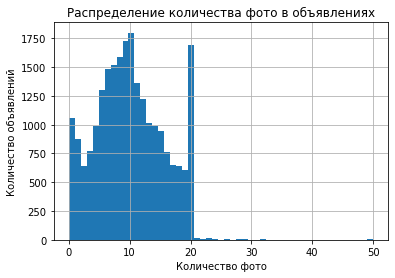

```python
column_describe('total_images')
# Посмотрим распределение количества фото в объявлениях
data['total_images'].hist(bins=51, grid=True)
plt.title('Распределение количества фото в объявлениях')
plt.xlabel("Количество фото")
plt.ylabel("Количество объявлений")
```

```python
display(data.query('total_images == 0').sample(10))
display(data.query('total_images == 1').sample(10))
display(data.query('total_images == 21').sample(10))
```

|  | total_images | last_price | total_area | first_day_exposition | rooms | ceiling_height | floors_total | living_area | floor | is_apartment | ... | kitchen_area | balcony | locality_name | airports_nearest | city_centers_nearest | parks_around_3000 | parks_nearest | ponds_around_3000 | ponds_nearest | days_exposition |
| --- | --- | --- | --- | --- | --- | --- | --- | --- | --- | --- | --- | --- | --- | --- | --- | --- | --- | --- | --- | --- | --- |
| 9232 | 0 | 3990000.0 | 51.0 | 2017-06-03T00:00:00 | 2 | NaN | 9.0 | 31.5 | 3 | NaN | ... | 9.0 | 2.0 | Санкт-Петербург | 12444.0 | 15035.0 | 0.0 | NaN | 1.0 | 881.0 | 100.0 |
| 2235 | 0 | 3700000.0 | 45.3 | 2014-12-22T00:00:00 | 2 | NaN | 5.0 | 29.8 | 2 | NaN | ... | 6.8 | 0.0 | Санкт-Петербург | 19068.0 | 10599.0 | 0.0 | NaN | 1.0 | 736.0 | 946.0 |
| 4881 | 0 | 2400000.0 | 35.5 | 2018-07-21T00:00:00 | 1 | 2.50 | 17.0 | 14.6 | 6 | NaN | ... | 8.3 | NaN | Кировск | NaN | NaN | NaN | NaN | NaN | NaN | 3.0 |
| 18468 | 0 | 6800000.0 | 70.0 | 2018-02-01T00:00:00 | 2 | 3.00 | 5.0 | 41.0 | 4 | NaN | ... | 12.0 | NaN | Санкт-Петербург | 24656.0 | 2986.0 | 1.0 | 69.0 | 1.0 | 929.0 | 115.0 |
| 20941 | 0 | 4350000.0 | 58.0 | 2016-10-05T00:00:00 | 2 | NaN | 27.0 | 28.0 | 16 | NaN | ... | 15.0 | 1.0 | посёлок Мурино | NaN | NaN | NaN | NaN | NaN | NaN | 362.0 |
| 9338 | 0 | 4000000.0 | 44.5 | 2017-09-30T00:00:00 | 2 | NaN | 12.0 | 26.5 | 9 | NaN | ... | 6.1 | 0.0 | Санкт-Петербург | 36294.0 | 10652.0 | 0.0 | NaN | 0.0 | NaN | 5.0 |
| 8396 | 0 | 6150000.0 | 58.3 | 2016-05-23T00:00:00 | 2 | 2.55 | 10.0 | 31.0 | 9 | NaN | ... | 10.0 | 2.0 | Санкт-Петербург | 49136.0 | 16806.0 | 0.0 | NaN | 0.0 | NaN | 147.0 |
| 20078 | 0 | 5100000.0 | 55.0 | 2018-08-16T00:00:00 | 3 | 2.55 | 5.0 | 40.0 | 4 | NaN | ... | 6.0 | 1.0 | Пушкин | 17236.0 | 29389.0 | 1.0 | 245.0 | 1.0 | 928.0 | 12.0 |
| 6602 | 0 | 2700000.0 | 32.9 | 2017-08-12T00:00:00 | 1 | NaN | 4.0 | 15.7 | 1 | NaN | ... | 6.8 | NaN | Колпино | 24870.0 | 30656.0 | 3.0 | 288.0 | 3.0 | 456.0 | 125.0 |
| 3795 | 0 | 3200000.0 | 48.0 | 2018-12-16T00:00:00 | 1 | NaN | 4.0 | 25.0 | 2 | NaN | ... | 9.0 | NaN | посёлок Металлострой | 24813.0 | 27803.0 | 0.0 | NaN | 0.0 | NaN | 60.0 |

10 rows × 22 columns

|  | total_images | last_price | total_area | first_day_exposition | rooms | ceiling_height | floors_total | living_area | floor | is_apartment | ... | kitchen_area | balcony | locality_name | airports_nearest | city_centers_nearest | parks_around_3000 | parks_nearest | ponds_around_3000 | ponds_nearest | days_exposition |
| --- | --- | --- | --- | --- | --- | --- | --- | --- | --- | --- | --- | --- | --- | --- | --- | --- | --- | --- | --- | --- | --- |
| 23188 | 1 | 11000000.0 | 81.00 | 2018-01-01T00:00:00 | 3 | 3.00 | 11.0 | 47.00 | 4 | NaN | ... | 16.00 | 2.0 | Санкт-Петербург | 31744.0 | 4836.0 | 0.0 | NaN | 3.0 | 153.0 | 95.0 |
| 23110 | 1 | 2900000.0 | 34.00 | 2018-02-01T00:00:00 | 2 | 2.90 | 2.0 | 20.00 | 1 | NaN | ... | 4.00 | NaN | посёлок Стрельна | 27006.0 | 23832.0 | 0.0 | NaN | 2.0 | 872.0 | 196.0 |
| 13695 | 1 | 4800000.0 | 59.00 | 2018-02-20T00:00:00 | 2 | NaN | 6.0 | 36.00 | 1 | NaN | ... | 10.00 | NaN | Санкт-Петербург | 19845.0 | 3594.0 | 1.0 | 350.0 | 1.0 | 196.0 | 56.0 |
| 20203 | 1 | 2690000.0 | 36.00 | 2017-08-22T00:00:00 | 1 | NaN | 9.0 | 21.00 | 4 | NaN | ... | 7.00 | NaN | Колпино | 23695.0 | 29481.0 | 0.0 | NaN | 1.0 | 275.0 | 178.0 |
| 8800 | 1 | 6500000.0 | 71.00 | 2018-10-29T00:00:00 | 3 | 2.50 | 12.0 | 47.50 | 11 | NaN | ... | 9.00 | 1.0 | Санкт-Петербург | 9782.0 | 11901.0 | 2.0 | 542.0 | 1.0 | 579.0 | 26.0 |
| 9100 | 1 | 7200000.0 | 69.70 | 2017-06-21T00:00:00 | 3 | 2.65 | 12.0 | 46.20 | 1 | NaN | ... | 10.50 | 0.0 | Санкт-Петербург | 13991.0 | 12787.0 | 0.0 | NaN | 0.0 | NaN | 98.0 |
| 18722 | 1 | 6990000.0 | 60.00 | 2015-10-14T00:00:00 | 2 | NaN | 25.0 | 29.00 | 7 | NaN | ... | 11.00 | 1.0 | Санкт-Петербург | 16749.0 | 14833.0 | 1.0 | 889.0 | 0.0 | NaN | 285.0 |
| 16463 | 1 | 3500000.0 | 56.00 | 2017-02-12T00:00:00 | 1 | NaN | 23.0 | 21.00 | 7 | NaN | ... | 15.00 | 0.0 | посёлок Шушары | 12526.0 | 18312.0 | 0.0 | NaN | 0.0 | NaN | 139.0 |
| 13580 | 1 | 2820000.0 | 33.07 | 2018-03-22T00:00:00 | 1 | 2.56 | 18.0 | 13.37 | 17 | False | ... | 8.31 | NaN | посёлок Бугры | NaN | NaN | NaN | NaN | NaN | NaN | 26.0 |
| 23585 | 1 | 5953044.0 | 89.60 | 2015-09-03T00:00:00 | 3 | 2.75 | 23.0 | 47.70 | 17 | NaN | ... | 16.70 | NaN | Санкт-Петербург | 26726.0 | 8880.0 | 0.0 | NaN | 1.0 | 624.0 | 939.0 |

10 rows × 22 columns

|  | total_images | last_price | total_area | first_day_exposition | rooms | ceiling_height | floors_total | living_area | floor | is_apartment | ... | kitchen_area | balcony | locality_name | airports_nearest | city_centers_nearest | parks_around_3000 | parks_nearest | ponds_around_3000 | ponds_nearest | days_exposition |
| --- | --- | --- | --- | --- | --- | --- | --- | --- | --- | --- | --- | --- | --- | --- | --- | --- | --- | --- | --- | --- | --- |
| 19030 | 21 | 7270000.0 | 69.9 | 2017-11-29T00:00:00 | 3 | NaN | 12.0 | 41.7 | 2 | NaN | ... | 10.8 | NaN | Санкт-Петербург | 35472.0 | 11374.0 | 0.0 | NaN | 2.0 | 633.0 | 55.0 |
| 13953 | 21 | 3255000.0 | 28.2 | 2017-09-26T00:00:00 | 0 | NaN | 24.0 | 20.0 | 2 | NaN | ... | NaN | NaN | Санкт-Петербург | 41466.0 | 11538.0 | 0.0 | NaN | 0.0 | NaN | 119.0 |
| 10672 | 21 | 2750000.0 | 72.1 | 2018-02-01T00:00:00 | 3 | NaN | 5.0 | 46.5 | 1 | NaN | ... | 8.2 | 2.0 | посёлок Новый Свет | NaN | NaN | NaN | NaN | NaN | NaN | 5.0 |
| 20677 | 21 | 5800000.0 | 44.0 | 2016-11-06T00:00:00 | 1 | NaN | 22.0 | 20.0 | 7 | NaN | ... | 10.5 | 2.0 | Санкт-Петербург | 13069.0 | 10763.0 | 0.0 | NaN | 1.0 | 613.0 | 465.0 |
| 20289 | 21 | 6750000.0 | 71.8 | 2017-10-07T00:00:00 | 3 | 3.0 | 8.0 | 36.9 | 4 | NaN | ... | 16.2 | 2.0 | Санкт-Петербург | 16664.0 | 15666.0 | 0.0 | NaN | 1.0 | 517.0 | 103.0 |
| 12907 | 21 | 10800000.0 | 70.6 | 2017-09-26T00:00:00 | 2 | NaN | 24.0 | 37.4 | 22 | NaN | ... | 13.5 | 2.0 | Санкт-Петербург | 11425.0 | 13107.0 | 0.0 | NaN | 0.0 | NaN | 13.0 |
| 14875 | 21 | 5290000.0 | 44.9 | 2017-08-12T00:00:00 | 2 | NaN | 9.0 | 26.8 | 9 | NaN | ... | 6.2 | 2.0 | Санкт-Петербург | 12403.0 | 10787.0 | 0.0 | NaN | 1.0 | 713.0 | 90.0 |
| 5280 | 21 | 6750000.0 | 72.0 | 2017-06-07T00:00:00 | 3 | NaN | 13.0 | 43.5 | 6 | False | ... | 8.4 | 1.0 | Санкт-Петербург | 32708.0 | 13872.0 | 0.0 | NaN | 0.0 | NaN | 86.0 |
| 3301 | 21 | 4950000.0 | 46.4 | 2017-12-07T00:00:00 | 2 | NaN | 25.0 | 16.6 | 2 | NaN | ... | 11.0 | 1.0 | деревня Кудрово | NaN | NaN | NaN | NaN | NaN | NaN | 47.0 |
| 7706 | 21 | 6950000.0 | 78.0 | 2018-03-13T00:00:00 | 2 | 3.4 | 4.0 | 46.0 | 3 | NaN | ... | 10.2 | 1.0 | Санкт-Петербург | 19124.0 | 3220.0 | 0.0 | NaN | 2.0 | 290.0 | 9.0 |

10 rows × 22 columns

**Вывод**

### Столбец last_price — цена на момент снятия с публикации

```
Количество пропусков в столбце last_price: 0
Тип переменной в столбце last_price: float64
```

```
count    2.369900e+04
mean     6.541549e+06
std      1.088701e+07
min      1.219000e+04
25%      3.400000e+06
50%      4.650000e+06
75%      6.800000e+06
max      7.630000e+08
Name: last_price, dtype: float64
```

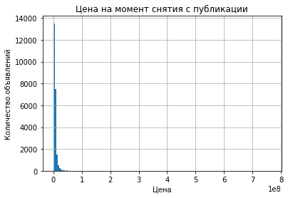

```python
column_describe('last_price')
# Посмотрим распределение цены в объявлениях
data['last_price'].hist(bins=150, grid=True)
plt.title('Цена на момент снятия с публикации')
plt.xlabel("Цена")
plt.ylabel("Количество объявлений")
```

Определим количество уникальных значений.

```python
data['last_price'].value_counts().head(15)
```

```
4500000.0    342
3500000.0    291
4000000.0    260
4300000.0    260
4200000.0    259
3600000.0    257
3300000.0    244
3800000.0    240
3200000.0    238
3700000.0    234
4100000.0    233
3400000.0    227
5500000.0    227
3900000.0    221
3100000.0    220
Name: last_price, dtype: int64
```

Есть большое количество малых значений, но распределение видно очень плохо. Посмотрим на распределение объявлений с ценой менее 1 млн. по населенным пунктам.

```python
data.query('last_price < 1000000')['locality_name'].value_counts().head(60)
```

```
Сланцы                                        83
Бокситогорск                                  14
Пикалёво                                      11
Ивангород                                      5
Выборг                                         4
Кириши                                         4
Луга                                           4
поселок городского типа Никольский             4
деревня Старополье                             3
деревня Торошковичи                            3
Подпорожье                                     3
поселок городского типа Ефимовский             3
посёлок городского типа Важины                 3
посёлок городского типа Кузнечное              3
Волхов                                         3
деревня Белогорка                              2
поселок Совхозный                              2
поселок городского типа Вырица                 2
посёлок Плодовое                               2
поселок Оредеж                                 2
поселок Серебрянский                           2
поселок станции Вещево                         2
поселок Глажево                                2
посёлок городского типа Вырица                 2
деревня Извара                                 2
деревня Выскатка                               2
деревня Коркино                                2
деревня Фалилеево                              2
деревня Ям-Тесово                              2
посёлок станции Свирь                          2
поселок Володарское                            1
поселок станции Лужайка                        1
посёлок Гаврилово                              1
Новая Ладога                                   1
деревня Большой Сабск                          1
поселок городского типа Синявино               1
поселок Пчевжа                                 1
поселок Цвылёво                                1
поселок Почап                                  1
деревня Большая Вруда                          1
поселок Ромашки                                1
Сясьстрой                                      1
поселок Тёсово-4                               1
Всеволожск                                     1
село Паша                                      1
Отрадное                                       1
поселок Громово                                1
поселок Красная Долина                         1
посёлок Шугозеро                               1
деревня Ялгино                                 1
деревня Пельгора                               1
деревня Бор                                    1
поселок городского типа Кондратьево            1
деревня Вахнова Кара                           1
Гатчина                                        1
деревня Торосово                               1
деревня Калитино                               1
посёлок при железнодорожной станции Вещево     1
поселок Житково                                1
деревня Сижно                                  1
Name: locality_name, dtype: int64
```

Все это маленькие города и деревни, для которых такая цена вполне реальна, кроме Санкт-Петербурга. Посмотрим на их удаление от центра Санкт-Петербурга.

```python
data.query('last_price < 1000000')['city_centers_nearest'].describe()
```

```
count       1.0
mean     9176.0
std         NaN
min      9176.0
25%      9176.0
50%      9176.0
75%      9176.0
max      9176.0
Name: city_centers_nearest, dtype: float64
```

Удаление от центра указано только у одного объявления, посмотрим его.

```python
data.query('last_price < 1000000 and city_centers_nearest < 10000')
```

|  | total_images | last_price | total_area | first_day_exposition | rooms | ceiling_height | floors_total | living_area | floor | is_apartment | ... | kitchen_area | balcony | locality_name | airports_nearest | city_centers_nearest | parks_around_3000 | parks_nearest | ponds_around_3000 | ponds_nearest | days_exposition |
| --- | --- | --- | --- | --- | --- | --- | --- | --- | --- | --- | --- | --- | --- | --- | --- | --- | --- | --- | --- | --- | --- |
| 8793 | 7 | 12190.0 | 109.0 | 2019-03-20T00:00:00 | 2 | 2.75 | 25.0 | 32.0 | 25 | NaN | ... | 40.5 | NaN | Санкт-Петербург | 36421.0 | 9176.0 | 1.0 | 805.0 | 0.0 | NaN | 8.0 |

1 rows × 22 columns

Это как раз и есть то объявление из Санкт-Петербурга. Большая часть значений заполнена, поэтому посмотрим на объявления с такими же параметрами.

```python
data.query('total_area > 100 and total_area < 110 and locality_name == "Санкт-Петербург" and floor == 25 and city_centers_nearest > 9100 and last_price > 13000')
```

|  | total_images | last_price | total_area | first_day_exposition | rooms | ceiling_height | floors_total | living_area | floor | is_apartment | ... | kitchen_area | balcony | locality_name | airports_nearest | city_centers_nearest | parks_around_3000 | parks_nearest | ponds_around_3000 | ponds_nearest | days_exposition |
| --- | --- | --- | --- | --- | --- | --- | --- | --- | --- | --- | --- | --- | --- | --- | --- | --- | --- | --- | --- | --- | --- |
| 14809 | 17 | 13300000.0 | 101.2 | 2018-03-03T00:00:00 | 3 | 2.75 | 25.0 | 55.4 | 25 | NaN | ... | 13.5 | 1.0 | Санкт-Петербург | 36533.0 | 9289.0 | 1.0 | 674.0 | 0.0 | NaN | 74.0 |

1 rows × 22 columns

Скорее всего при создании объявления цена была указана в тысячах рублей, т.е. реальная цена должна быть 12190000 руб.

```python
data.loc[8793, 'last_price'] = 12190000.0
```

Проверим аномально большие значения (более 99,5 квантиля).

```python
# Посмотрим на распределение объявлений по населенным пунктам
data.query('last_price > @data["last_price"].quantile(.995)')['locality_name'].value_counts()
```

```
Санкт-Петербург    119
Name: locality_name, dtype: int64
```

Сделаем сводную таблицу с медианными значениями параметров: `last_price`, `floor`, `floors_total`, `total_area`, `ceiling_height`.

```python
data.query('last_price > @data["last_price"].quantile(.995)').pivot_table(index='rooms', values=['last_price', 'total_area', 'floors_total', 'floor', 'ceiling_height'], aggfunc='median')
```

| rooms | ceiling_height | floor | floors_total | last_price | total_area |
| --- | --- | --- | --- | --- | --- |
| 0 | 3.57 | 6 | 7.0 | 71000000.0 | 371.000 |
| 2 | 3.37 | 3 | 9.0 | 65850000.0 | 146.000 |
| 3 | 3.30 | 5 | 8.0 | 77000000.0 | 166.000 |
| 4 | 3.20 | 4 | 7.5 | 75000000.0 | 205.000 |
| 5 | 3.50 | 4 | 5.0 | 89037500.0 | 281.500 |
| 6 | 3.50 | 5 | 6.0 | 84669500.0 | 277.475 |
| 7 | 3.80 | 5 | 7.0 | 110750000.0 | 415.500 |
| 8 | 3.90 | 8 | 8.0 | 150000000.0 | 347.000 |
| 9 | 2.50 | 1 | 2.0 | 88000000.0 | 400.000 |
| 12 | 2.80 | 25 | 25.0 | 420000000.0 | 900.000 |
| 15 | 3.50 | 3 | 6.0 | 65000000.0 | 590.000 |

Это квартиры c большой площадью и большими потолками - скорее всего это элитное жилье. Элитное жилье часто выделяют в отдельную категорию, так как ценообразование сильно отличается от остального рынка. Таких объявлений 119 (0,5%), чтобы они не влияли на анализ остальных объявлений, удалим их.

```python
print('Размер data до удаления:', data.shape)
# Удалим значение
for i in data.query('last_price > @data["last_price"].quantile(.995)').index:
    data.drop(labels = [i],axis = 0, inplace = True)
# Обнулим индексы
data = data.reset_index(drop=True)
# Проверим размер после удаления
print('Размер data после удаления:', data.shape)
```

```
Размер data до удаления: (23699, 22)
Размер data после удаления: (23580, 22)
```

**Вывод**

Столбец `last_price` не имеет пропущенных значений и имеет верный тип данных float64. Мы нашли аномалию в малых значениях и исправили ее, аномалии в больших значениях мы удалили, чтобы они не влияли на анализ, т.к. их мало и они отновятся к элитной недвижимости (огромная общая площадь, высокие потолки).

### Столбец rooms - число комнат

```
Количество пропусков в столбце rooms: 0
Тип переменной в столбце rooms: int64
```

```
count    23580.000000
mean         2.057718
std          1.056896
min          0.000000
25%          1.000000
50%          2.000000
75%          3.000000
max         19.000000
Name: rooms, dtype: float64
```

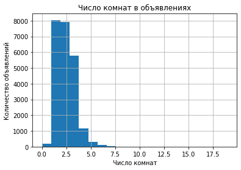

```python
column_describe('rooms')
data['rooms'].hist(bins=20)
plt.title('Число комнат в объявлениях')
plt.xlabel("Число комнат")
plt.ylabel("Количество объявлений")
```

```python
# Проверим соотношение количества комнат с площадями и балконами
data.pivot_table(index='rooms', values=['total_area','kitchen_area', 'living_area', 'balcony'], aggfunc=['median', 'mean'])
```

| rooms | median balcony | median kitchen_area | median living_area | median total_area | mean balcony | mean kitchen_area | mean living_area | mean total_area |
| --- | --- | --- | --- | --- | --- | --- | --- | --- |
| 0 | 2.0 | NaN | 18.00 | 26.025 | 1.579365 | NaN | 18.865246 | 27.536276 |
| 1 | 1.0 | 9.04 | 17.60 | 36.560 | 1.096263 | 9.550118 | 17.893552 | 37.644669 |
| 2 | 1.0 | 8.76 | 30.50 | 53.000 | 1.106615 | 9.962512 | 31.719428 | 55.797670 |
| 3 | 1.0 | 9.50 | 45.00 | 72.700 | 1.308764 | 11.182828 | 47.253690 | 77.263603 |
| 4 | 1.0 | 11.00 | 63.00 | 98.000 | 1.068627 | 13.340645 | 65.214915 | 104.579355 |
| 5 | 1.0 | 15.00 | 90.00 | 141.650 | 0.976378 | 16.633156 | 93.699630 | 149.147300 |
| 6 | 1.0 | 18.30 | 117.70 | 180.000 | 0.714286 | 20.362353 | 127.802386 | 190.615054 |
| 7 | 0.0 | 17.90 | 136.10 | 203.300 | 0.727273 | 19.977273 | 148.420000 | 228.653061 |
| 8 | 0.0 | 23.60 | 160.00 | 235.000 | 0.000000 | 21.342857 | 152.000000 | 240.077778 |
| 9 | 0.5 | 13.75 | 169.90 | 292.200 | 0.500000 | 20.916667 | 180.300000 | 292.542857 |
| 10 | 1.0 | 19.80 | 161.40 | 272.600 | 0.666667 | 22.866667 | 165.566667 | 259.566667 |
| 11 | NaN | 12.60 | 133.90 | 188.900 | NaN | 12.600000 | 133.900000 | 188.900000 |
| 14 | 0.0 | 21.25 | 195.15 | 304.200 | 0.000000 | 21.250000 | 195.150000 | 304.200000 |
| 16 | 1.0 | 13.00 | 180.00 | 270.000 | 1.000000 | 13.000000 | 180.000000 | 270.000000 |
| 19 | NaN | 27.60 | 264.50 | 374.600 | NaN | 27.600000 | 264.500000 | 374.600000 |

После 9 комнат площади перестают увеличиваться. Проверим сколько строк, в которых комнат более 9.

```python
data.query('rooms > 9')
```

|  | total_images | last_price | total_area | first_day_exposition | rooms | ceiling_height | floors_total | living_area | floor | is_apartment | ... | kitchen_area | balcony | locality_name | airports_nearest | city_centers_nearest | parks_around_3000 | parks_nearest | ponds_around_3000 | ponds_nearest | days_exposition |
| --- | --- | --- | --- | --- | --- | --- | --- | --- | --- | --- | --- | --- | --- | --- | --- | --- | --- | --- | --- | --- | --- |
| 642 | 3 | 17500000.0 | 183.7 | 2018-07-01T00:00:00 | 11 | 3.40 | 7.0 | 138.8 | 7 | NaN | ... | 13.3 | NaN | Санкт-Петербург | 23606.0 | 3148.0 | 0.0 | NaN | 0.0 | NaN | NaN |
| 859 | 5 | 25000000.0 | 363.0 | 2017-12-23T00:00:00 | 14 | 3.16 | 5.0 | 222.0 | 4 | NaN | ... | 16.6 | NaN | Санкт-Петербург | 38076.0 | 7950.0 | 0.0 | NaN | 2.0 | 435.0 | 418.0 |
| 4127 | 6 | 23000000.0 | 272.6 | 2018-01-11T00:00:00 | 10 | 3.14 | 7.0 | 145.9 | 7 | NaN | ... | 18.8 | 1.0 | Санкт-Петербург | 10726.0 | 12169.0 | 1.0 | 191.0 | 1.0 | 531.0 | NaN |
| 9637 | 8 | 33000000.0 | 194.1 | 2017-02-07T00:00:00 | 11 | 3.43 | 5.0 | 129.0 | 2 | NaN | ... | 11.9 | NaN | Санкт-Петербург | 21469.0 | 1015.0 | 1.0 | 686.0 | 2.0 | 66.0 | 813.0 |
| 14425 | 6 | 32250000.0 | 374.6 | 2018-06-09T00:00:00 | 19 | NaN | 5.0 | 264.5 | 2 | NaN | ... | 27.6 | NaN | Санкт-Петербург | 19497.0 | 3574.0 | 0.0 | NaN | 2.0 | 548.0 | 114.0 |
| 18027 | 4 | 15500000.0 | 216.1 | 2016-07-04T00:00:00 | 10 | 3.15 | 5.0 | 161.4 | 2 | NaN | ... | 19.8 | 0.0 | Санкт-Петербург | 24353.0 | 4921.0 | 1.0 | 368.0 | 0.0 | NaN | 11.0 |
| 18755 | 6 | 28500000.0 | 270.0 | 2015-03-02T00:00:00 | 16 | 3.00 | 4.0 | 180.0 | 4 | NaN | ... | 13.0 | 1.0 | Санкт-Петербург | 23575.0 | 4142.0 | 1.0 | 516.0 | 0.0 | NaN | 1365.0 |
| 18797 | 11 | 40000000.0 | 290.0 | 2016-06-21T00:00:00 | 10 | 3.50 | 6.0 | 189.4 | 6 | NaN | ... | 30.0 | 1.0 | Санкт-Петербург | 26229.0 | 4932.0 | 3.0 | 316.0 | 1.0 | 227.0 | 77.0 |
| 20724 | 6 | 28659000.0 | 245.4 | 2016-03-31T00:00:00 | 14 | NaN | 4.0 | 168.3 | 2 | NaN | ... | 25.9 | 0.0 | Санкт-Петербург | 21104.0 | 2054.0 | 3.0 | 541.0 | 2.0 | 118.0 | 95.0 |

9 rows × 22 columns

Значений более 9 очень мало. Исходя из площади, стоимости и высоты потолков - это элитная недвижимость. Объявлений с квартирами, в которых комнат более 9 всего 9 шт. - это менее 0,04% от изначальных данных. Также при росте значений cтолбца `rooms` до 9 наблюдается увеличение площадей, что говорит о правдивости данных, но при увеличении количества комнат после 9, площади не увеличиваются, и наблюдаются аномалии в других столбцах. Поэтому данные строки лучше удалить.

```python
print('Размер data до удаления:', data.shape)
# Удалим значение
for i in data.query('rooms > 9').index:
    data.drop(labels = [i],axis = 0, inplace = True)
# Обнулим индексы
data = data.reset_index(drop=True)
# Проверим размер после удаления
print('Размер data после удаления:', data.shape)
```

```
Размер data до удаления: (23580, 22)
Размер data после удаления: (23571, 22)
```

Составим сводную таблицу значений площадей в зависимости от количества комнат.

```python
data.pivot_table(index='rooms', values=['total_area','kitchen_area', 'living_area'], aggfunc=['min', 'mean', 'median','max'])
```

| rooms | min kitchen_area | min living_area | min total_area | mean kitchen_area | mean living_area | mean total_area | median kitchen_area | median living_area | median total_area | max kitchen_area | max living_area | max total_area |
| --- | --- | --- | --- | --- | --- | --- | --- | --- | --- | --- | --- | --- |
| 0 | NaN | 2.0 | 15.5 | NaN | 18.865246 | 27.536276 | NaN | 18.0 | 26.025 | NaN | 68.0 | 98.4 |
| 1 | 1.3 | 3.0 | 12.0 | 9.550118 | 17.893552 | 37.644669 | 9.04 | 17.6 | 36.560 | 58.4 | 60.0 | 494.1 |
| 2 | 2.0 | 2.0 | 20.0 | 9.962512 | 31.719428 | 55.797670 | 8.76 | 30.5 | 53.000 | 62.5 | 99.5 | 196.0 |
| 3 | 4.0 | 12.5 | 40.1 | 11.182828 | 47.253690 | 77.263603 | 9.50 | 45.0 | 72.700 | 100.7 | 170.8 | 263.8 |
| 4 | 4.8 | 5.4 | 42.0 | 13.340645 | 65.214915 | 104.579355 | 11.00 | 63.0 | 98.000 | 75.0 | 248.7 | 470.3 |
| 5 | 5.0 | 23.6 | 40.0 | 16.633156 | 93.699630 | 149.147300 | 15.00 | 90.0 | 141.650 | 65.0 | 182.0 | 422.2 |
| 6 | 5.9 | 51.0 | 87.0 | 20.362353 | 127.802386 | 190.615054 | 18.30 | 117.7 | 180.000 | 56.0 | 300.0 | 460.8 |
| 7 | 5.0 | 57.4 | 100.6 | 19.977273 | 148.420000 | 228.653061 | 17.90 | 136.1 | 203.300 | 53.1 | 332.0 | 517.0 |
| 8 | 5.0 | 107.0 | 150.0 | 21.342857 | 152.000000 | 240.077778 | 23.60 | 160.0 | 235.000 | 40.0 | 187.0 | 347.5 |
| 9 | 11.7 | 157.0 | 235.0 | 20.916667 | 180.300000 | 292.542857 | 13.75 | 169.9 | 292.200 | 41.0 | 225.9 | 398.0 |

Будем считать, что если `rooms` = 0, то значение потеряно, т.к не может быть студий площадью 98,4 метра.

Для всех строк, где `rooms` = 0, произведем замену в зависимости от площади.

За основу возьмем СНиП 31-01-2003, в котором указаны следующие критерии:

- 0 при значениях 28 > `total_area`
- 1 при значениях 28 < `total_area` <= 40
- 2 при значениях 40< `total_area` <= 54
- 3 при значениях 54< `total_area` <= 67
- 4 при значениях 67 < `total_area` <= 80
- 5 при значениях 80 < `total_area` <= 100
- 6 при значениях 100 < `total_area`.

```python
# Для всех строк, где rooms = 0, произведем замену в зависимости от площади
for i in data.query('rooms == 0 and total_area > 28 and total_area <= 40').index:
    data.loc[i, 'rooms'] = 1
for i in data.query('rooms == 0 and total_area > 40 and total_area <= 54').index:
    data.loc[i, 'rooms'] = 2
for i in data.query('rooms == 0 and total_area > 54 and total_area <= 67').index:
    data.loc[i, 'rooms'] = 3
for i in data.query('rooms == 0 and total_area > 67 and total_area <= 80').index:
    data.loc[i, 'rooms'] = 4
for i in data.query('rooms == 0 and total_area > 80 and total_area <= 100').index:
    data.loc[i, 'rooms'] = 5
for i in data.query('rooms == 0 and total_area > 100').index:
    data.loc[i, 'rooms'] = 6
```

```python
# Посмотрим на распределение площадей кухонь в студиях
data.query('rooms == 0')['kitchen_area'].value_counts()
```

```
Series([], Name: kitchen_area, dtype: int64)
```

Для квартир-студий (`rooms` = 0) значение `kitchen_area` соответствует NaN, что вполне понятно, ведь отдельной кухни в студии быть не может. Площадь кухни входит в жилую площадь. Заменим пропущенные значения на 0.

```python
# Заменим пропущенные значения на 0
for i in data.query('rooms == 0').index:
    data.loc[i, 'kitchen_area'] = 0
```

```python
# Для всех студий в столбце is_studio присвоим True
for i in data.query('rooms == 0').index:
    data.loc[i, 'is_studio'] = True
```

**Вывод**

Мы произвели чистку данных и в столбце `rooms` оставили только значения от 0 до 9.

Для `rooms` = 0 произвели замену согласно значениям `total_area`.

Для квартир-студий (`rooms` = 0):

- отсутствующие значение `kitchen_area` заменили на 0;
- в столбце `is_studio` проставили значение True.

Данный столбец не имеет отсутствующих значений и имеет верный тип данных int64, т.к. количество комнат - целое число.

### Столбец first_day_exposition - дата публикации

```python
column_describe('first_day_exposition')
```

```
Количество пропусков в столбце first_day_exposition: 0
Тип переменной в столбце first_day_exposition: object
```

```
count                   23571
unique                   1489
top       2018-02-01T00:00:00
freq                      367
Name: first_day_exposition, dtype: object
```

В данном столбце данные имеют тип object, что неверно. Изменим его на datetime. Так как в таблице отсутствуют значения часов, минут, секунд, то нет смысла указывать их в формате.

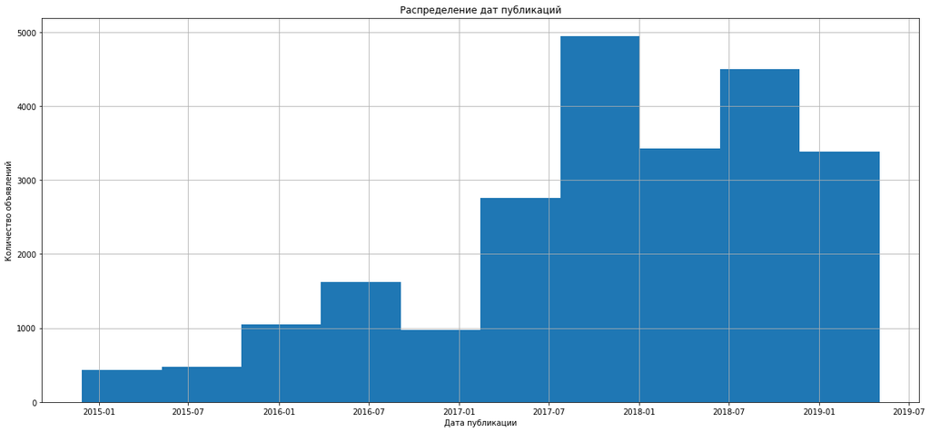

```python
# изменим тип на datetime
data['first_day_exposition'] = pd.to_datetime(data['first_day_exposition'], format='%Y-%m-%d')
data['first_day_exposition'].hist(figsize=(20, 9))
plt.title('Распределение дат публикаций')
plt.xlabel("Дата публикации")
plt.ylabel("Количество объявлений")
```

**Вывод**

Столбец first_day_exposition не имеет пропусков, большая часть значений лежит в диапазоне от 02.2017 до 05.2019. Тип данных для столбца изменен на datetime64 для упрощения операций со временем.

### Столбец is_studio - квартира-студия (булев тип)

```python
column_describe('is_studio')
# Посмотрим распределение студий в зависимости от количества комнат
data.query('is_studio').pivot_table(index='rooms', values='total_area', aggfunc='count')
```

```
Количество пропусков в столбце is_studio: 0
Тип переменной в столбце is_studio: bool
```

```
count     23571
unique        2
top       False
freq      23381
Name: is_studio, dtype: object
```

| rooms | total_area |
| --- | --- |
| 0 | 141 |
| 1 | 42 |
| 2 | 3 |
| 3 | 1 |
| 4 | 2 |
| 5 | 1 |

**Вывод**

Как оказывается такое может быть, поэтому оставим данные строки без изменений. Столбец имеет верный тип данных (bool).

### Столбец is_open_plan - свободная планировка (булев тип)

```python
column_describe('is_open_plan')
# Посмотрим распределение студий в зависимости от количества комнат
display(data.query('is_open_plan').pivot_table(index='rooms', values='total_area', aggfunc='count'))
```

```
Количество пропусков в столбце is_open_plan: 0
Тип переменной в столбце is_open_plan: bool
```

```
count     23571
unique        2
top       False
freq      23505
Name: is_open_plan, dtype: object
```

| rooms | total_area |
| --- | --- |
| 0 | 41 |
| 1 | 19 |
| 2 | 2 |
| 3 | 2 |
| 4 | 1 |
| 5 | 1 |

**Вывод**

В столбце is_studio пропущенных значений нет. Произвести оценку верности данных невозможно, поэтому оставим его без изменений. Столбец имеет верный тип данных (bool).

### Столбец balcony - число балконов

```python
column_describe('balcony')
```

```
Количество пропусков в столбце balcony: 11454
Тип переменной в столбце balcony: float64
```

```
count    12117.000000
mean         1.152100
std          1.070889
min          0.000000
25%          0.000000
50%          1.000000
75%          2.000000
max          5.000000
Name: balcony, dtype: float64
```

Отсутствует около 48% данных. Будем считать, что если данные отсутствуют, то балконов нет. Заменим отсутствующие значения на 0.

```python
# Замена отсутствующих значений на 0
data['balcony'] = data['balcony'].fillna(value=0)
```

```python
# Посмотрим на распределение после замены
column_describe('balcony')
```

```
Количество пропусков в столбце balcony: 0
Тип переменной в столбце balcony: float64
```

```
count    23571.000000
mean         0.592253
std          0.959736
min          0.000000
25%          0.000000
50%          0.000000
75%          1.000000
max          5.000000
Name: balcony, dtype: float64
```

```python
# Изменим тип данных на int64
data['balcony'] = data['balcony'].astype('int')
```

**Вывод**

В столбце balcony строк с пропущенными значениями около 48%. Искать причины при таком объеме потери данных нет смысла. Возможно, люди при отсутствии балконов оставляют данные поля пустыми. Все потерянные значения были заменены на 0. После заполнения отсутствующих значений столбец имеет верный тип int64, т.к. количество балконов - целое значение.

### Столбец floor - этаж

```
Количество пропусков в столбце floor: 0
Тип переменной в столбце floor: int64
```

```
count    23571.000000
mean         5.895550
std          4.892371
min          1.000000
25%          2.000000
50%          4.000000
75%          8.000000
max         33.000000
Name: floor, dtype: float64
```

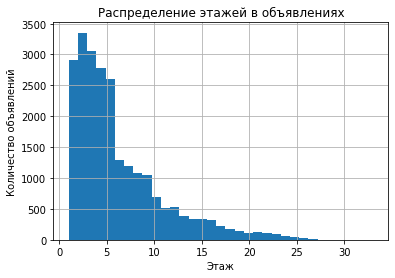

```python
column_describe('floor')
data['floor'].hist(bins=33)
plt.title('Распределение этажей в объявлениях')
plt.xlabel("Этаж")
plt.ylabel("Количество объявлений")
```

```python
# Проверим если ли значения, которые больше, чем соответствующие значения столбца floors_total
data.query('floor > floors_total')
```

|  | total_images | last_price | total_area | first_day_exposition | rooms | ceiling_height | floors_total | living_area | floor | is_apartment | ... | kitchen_area | balcony | locality_name | airports_nearest | city_centers_nearest | parks_around_3000 | parks_nearest | ponds_around_3000 | ponds_nearest | days_exposition |
| --- | --- | --- | --- | --- | --- | --- | --- | --- | --- | --- | --- | --- | --- | --- | --- | --- | --- | --- | --- | --- | --- |

0 rows × 22 columns

```python
# Посмотрим есть ли взаимосвязь между объявлениями на первом этаже
data.query('floor == 1').sample(10)
```

|  | total_images | last_price | total_area | first_day_exposition | rooms | ceiling_height | floors_total | living_area | floor | is_apartment | ... | kitchen_area | balcony | locality_name | airports_nearest | city_centers_nearest | parks_around_3000 | parks_nearest | ponds_around_3000 | ponds_nearest | days_exposition |
| --- | --- | --- | --- | --- | --- | --- | --- | --- | --- | --- | --- | --- | --- | --- | --- | --- | --- | --- | --- | --- | --- |
| 12614 | 8 | 12000000.0 | 126.0 | 2017-12-01 | 3 | 2.55 | 9.0 | 90.00 | 1 | NaN | ... | 15.0 | 0 | Санкт-Петербург | 28529.0 | 14247.0 | 0.0 | NaN | 1.0 | 801.0 | 90.0 |
| 16829 | 9 | 5300000.0 | 40.0 | 2018-09-12 | 1 | 2.80 | 5.0 | 18.00 | 1 | NaN | ... | 12.0 | 0 | Санкт-Петербург | 30776.0 | 6140.0 | 0.0 | NaN | 2.0 | 777.0 | 207.0 |
| 3962 | 5 | 2950000.0 | 36.3 | 2016-12-28 | 1 | NaN | 5.0 | 15.25 | 1 | NaN | ... | 11.7 | 0 | Санкт-Петербург | 47039.0 | 25599.0 | 1.0 | 126.0 | 1.0 | 979.0 | 159.0 |
| 14558 | 7 | 1330000.0 | 31.5 | 2017-12-07 | 1 | 2.60 | 5.0 | 17.30 | 1 | NaN | ... | 5.7 | 0 | деревня Лопухинка | NaN | NaN | NaN | NaN | NaN | NaN | 65.0 |
| 20787 | 7 | 3100000.0 | 34.0 | 2018-08-08 | 1 | NaN | 9.0 | 15.00 | 1 | NaN | ... | 10.0 | 0 | посёлок Бугры | NaN | NaN | NaN | NaN | NaN | NaN | 22.0 |
| 18013 | 8 | 2250000.0 | 53.6 | 2017-09-05 | 2 | NaN | 4.0 | 32.00 | 1 | NaN | ... | 8.7 | 0 | Волосово | NaN | NaN | NaN | NaN | NaN | NaN | 208.0 |
| 4388 | 9 | 2650000.0 | 54.5 | 2017-06-29 | 2 | 2.50 | 5.0 | 29.30 | 1 | NaN | ... | 8.8 | 0 | Кировск | NaN | NaN | NaN | NaN | NaN | NaN | 56.0 |
| 13988 | 8 | 1400000.0 | 24.0 | 2017-05-24 | 0 | NaN | 25.0 | 14.00 | 1 | NaN | ... | 0.0 | 0 | посёлок Парголово | 55551.0 | 21226.0 | 0.0 | NaN | 0.0 | NaN | 60.0 |
| 6719 | 13 | 1950000.0 | 44.6 | 2018-06-14 | 2 | NaN | 5.0 | NaN | 1 | NaN | ... | NaN | 0 | Тихвин | NaN | NaN | NaN | NaN | NaN | NaN | 75.0 |
| 23260 | 7 | 5600000.0 | 50.0 | 2017-08-21 | 1 | NaN | 5.0 | 27.00 | 1 | NaN | ... | 10.0 | 0 | Санкт-Петербург | 19585.0 | 2659.0 | 1.0 | 394.0 | 3.0 | 56.0 | 45.0 |

10 rows × 22 columns

### Столбец floors_total - всего этажей в доме

```
Количество пропусков в столбце floors_total: 86
Тип переменной в столбце floors_total: float64
```

```
count    23485.000000
mean        10.693208
std          6.605699
min          1.000000
25%          5.000000
50%          9.000000
75%         16.000000
max         60.000000
Name: floors_total, dtype: float64
```

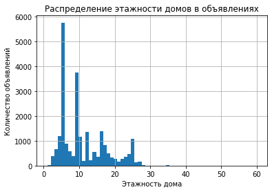

```python
column_describe('floors_total')
data['floors_total'].hist(bins=60)
plt.title('Распределение этажности домов в объявлениях')
plt.xlabel("Этажность дома")
plt.ylabel("Количество объявлений")
```

График рваный, что говорит об аномалиях.

В столбце 86 отсутствующих значений. Заменим их нулевыми значениями и продолжим анализ.

```python
data['floors_total'] = data['floors_total'].fillna(value=0)
```

```python
# Изучим распределение остутствующих значений по населенным пунктам
data.query('floors_total == 0').pivot_table(index='locality_name', values='rooms', aggfunc='count')
```

| locality_name | rooms |
| --- | --- |
| Красное Село | 2 |
| Кудрово | 2 |
| Санкт-Петербург | 70 |
| городской посёлок Новоселье | 1 |
| деревня Новое Девяткино | 1 |
| поселок Мурино | 2 |
| поселок городского типа Токсово | 1 |
| посёлок Бугры | 1 |
| посёлок Мурино | 2 |
| посёлок Стрельна | 1 |
| посёлок Шушары | 1 |
| посёлок Щеглово | 1 |

```python
# Посмотрим на распределение значений в столбцах
data.query('floors_total == 0').describe()
```

|  | total_images | last_price | total_area | rooms | ceiling_height | floors_total | living_area | floor | kitchen_area | balcony | airports_nearest | city_centers_nearest | parks_around_3000 | parks_nearest | ponds_around_3000 | ponds_nearest | days_exposition |
| --- | --- | --- | --- | --- | --- | --- | --- | --- | --- | --- | --- | --- | --- | --- | --- | --- | --- |
| count | 86.000000 | 8.600000e+01 | 86.000000 | 86.000000 | 9.000000 | 86.0 | 53.000000 | 86.000000 | 41.000000 | 86.000000 | 76.000000 | 76.000000 | 76.000000 | 34.000000 | 76.000000 | 49.000000 | 77.000000 |
| mean | 5.453488 | 6.814282e+06 | 62.537674 | 1.941860 | 2.777778 | 0.0 | 32.435849 | 10.023256 | 13.016098 | 0.046512 | 30141.184211 | 15666.710526 | 0.605263 | 549.941176 | 0.802632 | 475.714286 | 181.896104 |
| std | 4.010741 | 5.551092e+06 | 37.178265 | 1.066657 | 0.106393 | 0.0 | 19.019650 | 6.210005 | 6.365362 | 0.303198 | 13720.664002 | 6999.313903 | 0.784499 | 529.757975 | 0.748683 | 243.730811 | 232.229899 |
| min | 0.000000 | 1.640000e+06 | 23.170000 | 0.000000 | 2.650000 | 0.0 | 10.000000 | 1.000000 | 0.000000 | 0.000000 | 7050.000000 | 3148.000000 | 0.000000 | 24.000000 | 0.000000 | 130.000000 | 3.000000 |
| 25% | 3.000000 | 3.480000e+06 | 35.842500 | 1.000000 | 2.700000 | 0.0 | 17.500000 | 5.000000 | 10.300000 | 0.000000 | 21570.750000 | 11303.750000 | 0.000000 | 251.000000 | 0.000000 | 350.000000 | 49.000000 |
| 50% | 5.000000 | 5.192500e+06 | 55.950000 | 2.000000 | 2.800000 | 0.0 | 31.000000 | 8.000000 | 12.100000 | 0.000000 | 25892.000000 | 14637.000000 | 0.000000 | 400.000000 | 1.000000 | 374.000000 | 111.000000 |
| 75% | 8.750000 | 7.523265e+06 | 76.725000 | 3.000000 | 2.800000 | 0.0 | 45.380000 | 13.750000 | 15.000000 | 0.000000 | 40679.000000 | 17369.000000 | 1.000000 | 655.250000 | 1.000000 | 652.000000 | 183.000000 |
| max | 19.000000 | 4.034825e+07 | 284.000000 | 6.000000 | 3.000000 | 0.0 | 104.760000 | 24.000000 | 40.000000 | 2.000000 | 61908.000000 | 34085.000000 | 3.000000 | 2276.000000 | 3.000000 | 1158.000000 | 1257.000000 |

```python
# Посмотрим на распределение объявлений с отсутствующим значением floors_total по этажам
data.query('floors_total == 0').pivot_table(index='floor', values='rooms', aggfunc='count')
```

| floor | rooms |
| --- | --- |
| 1 | 3 |
| 2 | 2 |
| 3 | 4 |
| 4 | 10 |
| 5 | 4 |
| 6 | 9 |
| 7 | 4 |
| 8 | 8 |
| 9 | 5 |
| 10 | 3 |
| 11 | 3 |
| 12 | 6 |
| 13 | 3 |
| 14 | 2 |
| 15 | 3 |
| 17 | 1 |
| 18 | 3 |
| 19 | 3 |
| 20 | 2 |
| 21 | 4 |
| 22 | 1 |
| 23 | 1 |
| 24 | 2 |

Больше всего таких объявлений в Санкт-Петербурге. Взаимосвязи с другими столбцами нет.

Так как большую часть жилья в России представляет типовая застройка, то произведем замену значений на медианное по этажу квартиры.

```python
# Заменим на медианное значение
for i in data.query('floors_total == 0').index:
    floor = data.loc[i, 'floor']
    data.loc[i, 'floors_total'] = math.ceil(data.query('floor >= @floor')['floor'].median())
```

```python
# Изменим тип данных на int64
data['floors_total'] = data['floors_total'].astype('int')
# Определим преобладающую этажность
data['floors_total'].value_counts().head()
```

```
5     5763
9     3756
16    1376
12    1364
4     1190
Name: floors_total, dtype: int64
```

**Вывод**

### Столбец locality_name - название населённого пункта

```python
column_describe('locality_name')
```

```
Количество пропусков в столбце locality_name: 49
Тип переменной в столбце locality_name: object
```

```
count               23522
unique                364
top       Санкт-Петербург
freq                15593
Name: locality_name, dtype: object
```

Отсутствующих значений всего 49 (0.2%), заменим их на unknown.

```python
data['locality_name'] = data['locality_name'].fillna(value='unknown')
```

```python
# Посмотрим отсутствующие значения
data.query('locality_name == "unknown"').head(15)
```

|  | total_images | last_price | total_area | first_day_exposition | rooms | ceiling_height | floors_total | living_area | floor | is_apartment | ... | kitchen_area | balcony | locality_name | airports_nearest | city_centers_nearest | parks_around_3000 | parks_nearest | ponds_around_3000 | ponds_nearest | days_exposition |
| --- | --- | --- | --- | --- | --- | --- | --- | --- | --- | --- | --- | --- | --- | --- | --- | --- | --- | --- | --- | --- | --- |
| 1086 | 3 | 8600000.0 | 81.7 | 2016-04-15 | 3 | 3.55 | 5 | 50.80 | 2 | NaN | ... | 8.80 | 0 | unknown | 23478.0 | 4258.0 | 0.0 | NaN | 0.0 | NaN | 147.0 |
| 2013 | 6 | 5398000.0 | 80.0 | 2017-05-30 | 3 | NaN | 4 | 42.60 | 2 | NaN | ... | 18.60 | 0 | unknown | NaN | NaN | NaN | NaN | NaN | NaN | 34.0 |
| 2580 | 20 | 3351765.0 | 42.7 | 2015-09-20 | 1 | NaN | 24 | 15.60 | 3 | NaN | ... | 10.70 | 0 | unknown | 22041.0 | 17369.0 | 0.0 | NaN | 1.0 | 374.0 | 276.0 |
| 2609 | 2 | 5130593.0 | 62.4 | 2015-10-11 | 2 | NaN | 24 | 33.10 | 21 | NaN | ... | 8.20 | 0 | unknown | 22041.0 | 17369.0 | 0.0 | NaN | 1.0 | 374.0 | 256.0 |
| 3550 | 10 | 4200000.0 | 46.5 | 2016-05-28 | 2 | NaN | 5 | 30.80 | 5 | NaN | ... | 6.50 | 0 | unknown | 27419.0 | 8127.0 | 0.0 | NaN | 1.0 | 603.0 | 45.0 |
| 4126 | 17 | 17600000.0 | 89.5 | 2014-12-09 | 2 | 3.00 | 8 | 39.62 | 7 | NaN | ... | 13.38 | 0 | unknown | 25054.0 | 3902.0 | 1.0 | 485.0 | 3.0 | 722.0 | 869.0 |
| 4164 | 7 | 9200000.0 | 80.0 | 2015-12-10 | 3 | 4.00 | 4 | 52.30 | 3 | False | ... | 10.40 | 0 | unknown | 21774.0 | 3039.0 | 1.0 | 690.0 | 1.0 | 953.0 | 223.0 |
| 4644 | 1 | 5500000.0 | 83.0 | 2015-08-14 | 3 | NaN | 7 | NaN | 6 | NaN | ... | NaN | 0 | unknown | 26534.0 | 5382.0 | 1.0 | 446.0 | 1.0 | 376.0 | 350.0 |
| 5315 | 19 | 13540000.0 | 85.5 | 2016-01-20 | 3 | NaN | 7 | 59.10 | 5 | False | ... | 8.30 | 4 | unknown | 10556.0 | 9538.0 | 1.0 | 67.0 | 0.0 | NaN | 303.0 |
| 5676 | 7 | 3700000.0 | 30.0 | 2016-04-29 | 1 | NaN | 24 | 20.00 | 23 | NaN | ... | NaN | 0 | unknown | 21460.0 | 16788.0 | 0.0 | NaN | 1.0 | 170.0 | 49.0 |
| 6726 | 20 | 4895892.0 | 60.7 | 2015-03-12 | 2 | NaN | 24 | 31.90 | 3 | NaN | ... | 12.20 | 0 | unknown | 22041.0 | 17369.0 | 0.0 | NaN | 1.0 | 374.0 | 468.0 |
| 7074 | 5 | 4250000.0 | 56.0 | 2016-03-16 | 3 | NaN | 5 | 40.00 | 4 | NaN | ... | 6.00 | 0 | unknown | 14031.0 | 8582.0 | 0.0 | NaN | 0.0 | NaN | 96.0 |
| 7289 | 8 | 5100000.0 | 63.0 | 2015-01-27 | 3 | NaN | 5 | 42.00 | 1 | False | ... | 7.50 | 0 | unknown | 25925.0 | 4627.0 | 2.0 | 459.0 | 0.0 | NaN | 566.0 |
| 7556 | 8 | 6800000.0 | 70.0 | 2016-01-31 | 3 | NaN | 11 | 42.00 | 9 | NaN | ... | 11.00 | 1 | unknown | 37123.0 | 12332.0 | 0.0 | NaN | 0.0 | NaN | 209.0 |
| 8517 | 10 | 16000000.0 | 155.0 | 2016-05-09 | 3 | NaN | 6 | 94.00 | 3 | NaN | ... | 23.00 | 0 | unknown | 24233.0 | 4065.0 | 1.0 | 547.0 | 0.0 | NaN | 248.0 |

15 rows × 22 columns

Отсутствующие значения никак не связаны со значениями в других столбцах. Заполнить пропуски не получится. Так как строк мало, то их можно удалить.

```python
# Удаление строк
for i in data.query('locality_name == "unknown"').index:
    data.drop(labels = [i],axis = 0, inplace = True)
# Обнулим индексы
data = data.reset_index(drop=True)
```

```python
# Посмотрим на количественное распределение по городам
print('Уникальных населенных пунктов:', len(data['locality_name'].value_counts()))
data['locality_name'].value_counts().head(40)
```

```
Уникальных населенных пунктов: 364
```

```
Санкт-Петербург              15593
посёлок Мурино                 522
посёлок Шушары                 440
Всеволожск                     398
Пушкин                         369
Колпино                        338
посёлок Парголово              327
Гатчина                        307
деревня Кудрово                299
Выборг                         237
Петергоф                       201
Сестрорецк                     183
Красное Село                   178
Кудрово                        173
деревня Новое Девяткино        144
Сертолово                      142
Ломоносов                      133
Кириши                         125
Сланцы                         112
Волхов                         111
Кингисепп                      104
Тосно                          104
Кронштадт                       96
Никольское                      93
Коммунар                        89
Сосновый Бор                    87
Кировск                         84
Отрадное                        80
посёлок Бугры                   69
Приозерск                       66
посёлок Металлострой            66
деревня Старая                  64
городской посёлок Янино-1       61
Шлиссельбург                    57
Луга                            56
Тихвин                          49
поселок Бугры                   45
посёлок Стрельна                44
посёлок Тельмана                39
Павловск                        38
Name: locality_name, dtype: int64
```

Имеются неявные дубликаты, например 'поселок Бугры' и 'посёлок Бугры'. Заменим 'поселок' на 'посёлок'.

```python
for i in data.index:
    if 'поселок' in data.loc[i, 'locality_name']:
        data.loc[i, 'locality_name'] = data.loc[i, 'locality_name'].replace("поселок", "посёлок")
```

```python
# Посмотрим на количество уникальных городов после замены
print('Уникальных населенных пунктов:', len(data['locality_name'].value_counts()))
```

```
Уникальных населенных пунктов: 330
```

**Вывод**

В столбце `locality_name` удалено 49 строк с пропущенными значениями (0,2%). Взаимосвязи отсутствующих значений с другими столбцами нет. Были уделены неявные будликаты. Столбец имеет 330 уникальных значения. Столбец имеет верный тип данных (object).

### Столбец is_apartment — апартаменты (булев тип)

```python
column_describe('is_apartment')
```

```
Количество пропусков в столбце is_apartment: 20778
Тип переменной в столбце is_apartment: object
```

```
count      2744
unique        2
top       False
freq       2696
Name: is_apartment, dtype: object
```

**Вывод**

В столбце is_apartment строк с пропущенными значениями около 88.3 %. Искать причины при таком объеме потери данных нет смысла. Возможно люди оставляют данные поля пустыми. Тип данных столбеца нет смысла менять, так как тут смесь булевых значений с NaN (float).

### Столбецы kitchen_area, living_area, total_area

```
Количество пропусков в столбце kitchen_area: 2110
Тип переменной в столбце kitchen_area: float64
```

```
count    21412.000000
mean        10.375692
std          5.485316
min          0.000000
25%          7.000000
50%          9.000000
75%         12.000000
max        100.700000
Name: kitchen_area, dtype: float64
```

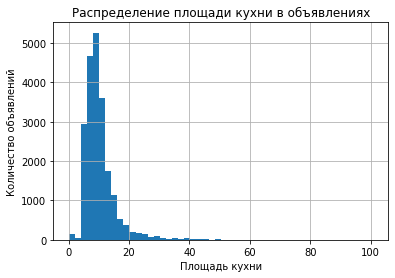

```python
column_describe('kitchen_area')
data['kitchen_area'].hist(bins=50, grid=True)
plt.title('Распределение площади кухни в объявлениях')
plt.xlabel("Площадь кухни")
plt.ylabel("Количество объявлений")
```

```
Количество пропусков в столбце living_area: 1882
Тип переменной в столбце living_area: float64
```

```
count    21640.000000
mean        33.850244
std         19.748219
min          2.000000
25%         18.600000
50%         30.000000
75%         42.000000
max        332.000000
Name: living_area, dtype: float64
```

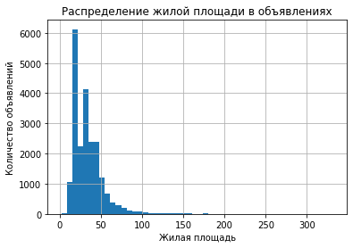

```python
column_describe('living_area')
data['living_area'].hist(bins=50, grid=True)
plt.title('Распределение жилой площади в объявлениях')
plt.xlabel("Жилая площадь")
plt.ylabel("Количество объявлений")
```

```
Количество пропусков в столбце total_area: 0
Тип переменной в столбце total_area: float64
```

```
count    23522.000000
mean        59.209401
std         31.012641
min         12.000000
25%         40.000000
50%         52.000000
75%         69.000000
max        517.000000
Name: total_area, dtype: float64
```

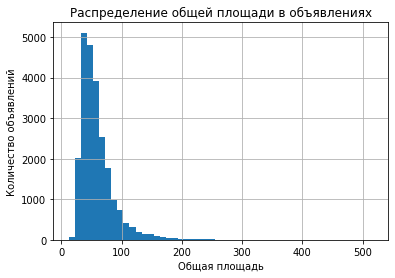

```python
column_describe('total_area')
data['total_area'].hist(bins=50, grid=True)
plt.title('Распределение общей площади в объявлениях')
plt.xlabel("Общая площадь")
plt.ylabel("Количество объявлений")
```

Столбец `living_area` рваный в отличии от `kitchen_area` и `total_area`.

Посмотрим распределение значений площадей в зависимости от количества комнат.

```python
data.pivot_table(index='rooms', values=['total_area','living_area', 'kitchen_area'], aggfunc=['min', 'median', 'max'])
```

| rooms | min kitchen_area | min living_area | min total_area | median kitchen_area | median living_area | median total_area | max kitchen_area | max living_area | max total_area |
| --- | --- | --- | --- | --- | --- | --- | --- | --- | --- |
| 0 | 0.0 | 2.0 | 15.5 | 0.000 | 17.4 | 25.0 | 0.0 | 25.0 | 28.0 |
| 1 | 1.3 | 3.0 | 12.0 | 9.010 | 17.6 | 36.5 | 58.4 | 60.0 | 494.1 |
| 2 | 2.0 | 2.0 | 20.0 | 8.745 | 30.5 | 53.0 | 62.5 | 99.5 | 196.0 |
| 3 | 4.0 | 12.5 | 40.1 | 9.500 | 45.0 | 72.6 | 100.7 | 170.8 | 263.8 |
| 4 | 4.8 | 5.4 | 42.0 | 11.000 | 63.1 | 98.0 | 75.0 | 248.7 | 470.3 |
| 5 | 5.0 | 23.6 | 40.0 | 15.000 | 90.0 | 141.3 | 65.0 | 182.0 | 422.2 |
| 6 | 5.9 | 51.0 | 87.0 | 18.300 | 117.7 | 180.0 | 56.0 | 300.0 | 460.8 |
| 7 | 5.0 | 57.4 | 100.6 | 17.900 | 136.1 | 203.3 | 53.1 | 332.0 | 517.0 |
| 8 | 5.0 | 107.0 | 150.0 | 23.600 | 160.0 | 235.0 | 40.0 | 187.0 | 347.5 |
| 9 | 11.7 | 157.0 | 235.0 | 13.750 | 169.9 | 292.2 | 41.0 | 225.9 | 398.0 |

Все нулевые значения в `kitchen_area` - это значения которые мы присваивали ранее. Нулевых значений в `living_area` нет. Заменим отсутствующие значения `kitchen_area` на медианные по количеству комнат, общей площади и этажу (из замены необходимо исключить студии, т.к. в них `kitchen_area` = 0).

```python
print('Количество пропущенных значений kitchen_area:', data['kitchen_area'].isna().sum())
# Заменим отсутствующие значения kitchen_area
data['kitchen_area'] = data['kitchen_area'].fillna(value=0)
for i in data.query('rooms != 0 and kitchen_area == 0').index:
        rooms_median = data.loc[i, 'rooms']
        floor_median = data.loc[i, 'floor']
        total_area_median = data.loc[i, 'total_area']
        data.loc[i, 'kitchen_area'] = data[(data['rooms'] == rooms_median) & (data['floor'] >= (floor_median - 1)) & (data['floor'] <= (floor_median + 1)) & (data['total_area'] >= (total_area_median - 10)) & (data['total_area'] <= (total_area_median + 10))]['kitchen_area'].median()
```

```
Количество пропущенных значений kitchen_area: 2110
```

```python
# Посмотрим на оставшиеся пропуски
data.query('rooms != 0 and kitchen_area == 0')
```

|  | total_images | last_price | total_area | first_day_exposition | rooms | ceiling_height | floors_total | living_area | floor | is_apartment | ... | kitchen_area | balcony | locality_name | airports_nearest | city_centers_nearest | parks_around_3000 | parks_nearest | ponds_around_3000 | ponds_nearest | days_exposition |
| --- | --- | --- | --- | --- | --- | --- | --- | --- | --- | --- | --- | --- | --- | --- | --- | --- | --- | --- | --- | --- | --- |
| 1114 | 2 | 8300000.0 | 96.50 | 2017-12-06 | 1 | 2.60 | 10 | NaN | 6 | NaN | ... | 0.0 | 0 | посёлок Бугры | NaN | NaN | NaN | NaN | NaN | NaN | 57.0 |
| 1571 | 3 | 1900000.0 | 21.89 | 2018-11-01 | 1 | NaN | 19 | 10.93 | 17 | NaN | ... | 0.0 | 0 | посёлок Бугры | NaN | NaN | NaN | NaN | NaN | NaN | 22.0 |
| 1797 | 3 | 1650000.0 | 22.00 | 2016-09-19 | 1 | NaN | 18 | 10.00 | 15 | NaN | ... | 0.0 | 0 | Никольское | NaN | NaN | NaN | NaN | NaN | NaN | 274.0 |
| 4291 | 5 | 25476800.0 | 160.00 | 2018-12-19 | 2 | NaN | 10 | NaN | 5 | NaN | ... | 0.0 | 0 | Санкт-Петербург | NaN | NaN | NaN | NaN | NaN | NaN | NaN |
| 5077 | 9 | 16900000.0 | 112.00 | 2019-01-24 | 2 | 3.00 | 8 | NaN | 8 | NaN | ... | 0.0 | 1 | Санкт-Петербург | 24484.0 | 5052.0 | 1.0 | 253.0 | 0.0 | NaN | NaN |
| 5832 | 0 | 38000000.0 | 400.00 | 2019-03-15 | 7 | 3.60 | 3 | NaN | 1 | NaN | ... | 0.0 | 0 | Санкт-Петербург | 24889.0 | 5457.0 | 1.0 | 271.0 | 0.0 | NaN | NaN |
| 7079 | 8 | 46000000.0 | 196.00 | 2016-07-21 | 2 | 3.20 | 10 | NaN | 2 | NaN | ... | 0.0 | 0 | Санкт-Петербург | 32537.0 | 6589.0 | 0.0 | NaN | 3.0 | 99.0 | 988.0 |
| 7520 | 11 | 2000000.0 | 20.60 | 2018-09-19 | 1 | NaN | 18 | 10.55 | 17 | NaN | ... | 0.0 | 0 | Никольское | NaN | NaN | NaN | NaN | NaN | NaN | NaN |
| 7673 | 4 | 5800000.0 | 70.00 | 2018-11-23 | 1 | NaN | 19 | NaN | 19 | NaN | ... | 0.0 | 0 | посёлок Мурино | NaN | NaN | NaN | NaN | NaN | NaN | 31.0 |
| 8793 | 12 | 17000000.0 | 235.00 | 2018-07-14 | 9 | 3.00 | 6 | NaN | 3 | NaN | ... | 0.0 | 0 | Санкт-Петербург | 24466.0 | 5034.0 | 1.0 | 346.0 | 0.0 | NaN | 90.0 |
| 9754 | 1 | 43185328.0 | 494.10 | 2017-05-12 | 1 | 2.85 | 12 | NaN | 3 | NaN | ... | 0.0 | 0 | Санкт-Петербург | 28529.0 | 6832.0 | 1.0 | 592.0 | 0.0 | NaN | 5.0 |
| 10108 | 9 | 35000000.0 | 295.00 | 2017-12-16 | 4 | NaN | 5 | NaN | 4 | NaN | ... | 0.0 | 0 | Санкт-Петербург | 26711.0 | 5559.0 | 0.0 | NaN | 1.0 | 785.0 | 90.0 |
| 10609 | 6 | 32894076.0 | 364.70 | 2019-05-02 | 7 | 3.32 | 3 | NaN | 1 | NaN | ... | 0.0 | 5 | Санкт-Петербург | NaN | NaN | NaN | NaN | NaN | NaN | NaN |
| 11356 | 4 | 24000000.0 | 316.30 | 2015-03-25 | 8 | NaN | 5 | 187.00 | 5 | NaN | ... | 0.0 | 0 | Санкт-Петербург | 24555.0 | 5129.0 | 0.0 | NaN | 1.0 | 934.0 | 542.0 |
| 12103 | 1 | 4900000.0 | 71.40 | 2017-09-21 | 5 | 2.60 | 9 | NaN | 7 | NaN | ... | 0.0 | 0 | Санкт-Петербург | 13592.0 | 14670.0 | 1.0 | 430.0 | 0.0 | NaN | 133.0 |
| 14500 | 12 | 13490000.0 | 100.60 | 2018-07-31 | 7 | NaN | 4 | NaN | 2 | True | ... | 0.0 | 0 | Санкт-Петербург | 24309.0 | 3876.0 | 3.0 | 574.0 | 3.0 | 325.0 | 50.0 |
| 14546 | 11 | 12990000.0 | 106.00 | 2018-07-08 | 6 | NaN | 4 | NaN | 1 | NaN | ... | 0.0 | 0 | Санкт-Петербург | 20417.0 | 3655.0 | 0.0 | NaN | 1.0 | 361.0 | 90.0 |
| 20110 | 5 | 13351000.0 | 102.70 | 2018-07-03 | 6 | 3.40 | 4 | 101.00 | 1 | NaN | ... | 0.0 | 0 | Санкт-Петербург | 24477.0 | 5464.0 | 2.0 | 519.0 | 0.0 | NaN | 229.0 |
| 21965 | 14 | 27000000.0 | 422.20 | 2018-10-18 | 5 | 2.70 | 13 | NaN | 11 | NaN | ... | 0.0 | 0 | Санкт-Петербург | 46625.0 | 16554.0 | 0.0 | NaN | 0.0 | NaN | NaN |
| 22150 | 1 | 17508600.0 | 184.30 | 2018-10-02 | 6 | 2.75 | 18 | NaN | 16 | NaN | ... | 0.0 | 0 | Санкт-Петербург | 37310.0 | 9782.0 | 1.0 | 497.0 | 0.0 | NaN | 56.0 |

20 rows × 22 columns

Из-за большого разброса значений, строгие правила не сработали, и малая часть строк осталась равна 0. Смягчим правила и заменим оставшиеся пропуски.

```python
# Заменим отсутствующие значения kitchen_area
for i in data.query('rooms != 0 and kitchen_area == 0').index:
        rooms_median = data.loc[i, 'rooms']
        floor_median = data.loc[i, 'floor']
        total_area_median = data.loc[i, 'total_area']
        data.loc[i, 'kitchen_area'] = data[(data['rooms'] == rooms_median) & (data['floor'] >= (floor_median - 3)) & (data['floor'] <= (floor_median + 3)) & (data['total_area'] >= (total_area_median - 20)) & (data['total_area'] <= (total_area_median + 20))]['kitchen_area'].median()
```

```python
data.query('rooms != 0 and kitchen_area == 0')
```

|  | total_images | last_price | total_area | first_day_exposition | rooms | ceiling_height | floors_total | living_area | floor | is_apartment | ... | kitchen_area | balcony | locality_name | airports_nearest | city_centers_nearest | parks_around_3000 | parks_nearest | ponds_around_3000 | ponds_nearest | days_exposition |
| --- | --- | --- | --- | --- | --- | --- | --- | --- | --- | --- | --- | --- | --- | --- | --- | --- | --- | --- | --- | --- | --- |
| 5832 | 0 | 38000000.0 | 400.0 | 2019-03-15 | 7 | 3.60 | 3 | NaN | 1 | NaN | ... | 0.0 | 0 | Санкт-Петербург | 24889.0 | 5457.0 | 1.0 | 271.0 | 0.0 | NaN | NaN |
| 7079 | 8 | 46000000.0 | 196.0 | 2016-07-21 | 2 | 3.20 | 10 | NaN | 2 | NaN | ... | 0.0 | 0 | Санкт-Петербург | 32537.0 | 6589.0 | 0.0 | NaN | 3.0 | 99.0 | 988.0 |
| 9754 | 1 | 43185328.0 | 494.1 | 2017-05-12 | 1 | 2.85 | 12 | NaN | 3 | NaN | ... | 0.0 | 0 | Санкт-Петербург | 28529.0 | 6832.0 | 1.0 | 592.0 | 0.0 | NaN | 5.0 |
| 11356 | 4 | 24000000.0 | 316.3 | 2015-03-25 | 8 | NaN | 5 | 187.0 | 5 | NaN | ... | 0.0 | 0 | Санкт-Петербург | 24555.0 | 5129.0 | 0.0 | NaN | 1.0 | 934.0 | 542.0 |
| 14500 | 12 | 13490000.0 | 100.6 | 2018-07-31 | 7 | NaN | 4 | NaN | 2 | True | ... | 0.0 | 0 | Санкт-Петербург | 24309.0 | 3876.0 | 3.0 | 574.0 | 3.0 | 325.0 | 50.0 |
| 21965 | 14 | 27000000.0 | 422.2 | 2018-10-18 | 5 | 2.70 | 13 | NaN | 11 | NaN | ... | 0.0 | 0 | Санкт-Петербург | 46625.0 | 16554.0 | 0.0 | NaN | 0.0 | NaN | NaN |

6 rows × 22 columns

Для оставшихся пропусков нет похожих объявлений. Из-за малого количества строк удалим данные строки.

```python
# Удаление строк
for i in data.query('rooms != 0 and kitchen_area == 0').index:
    data.drop(labels = [i],axis = 0, inplace = True)
# Обнулим индексы
data = data.reset_index(drop=True)
```

Заменим отсутствующие значения `living_area` на медианные по количеству комнат, общей площади и этажу).

```python
print('Количество пропущенных значений living_area:', data['living_area'].isna().sum())
# Заменим отсутствующие значения living_area
data['living_area'] = data['living_area'].fillna(value=0)
for i in data.query('living_area == 0').index:
        rooms_median = data.loc[i, 'rooms']
        floor_median = data.loc[i, 'floor']
        total_area_median = data.loc[i, 'total_area']
        data.loc[i, 'living_area'] = data[(data['rooms'] == rooms_median) & (data['floor'] >= (floor_median - 1)) & (data['floor'] <= (floor_median + 1)) & (data['total_area'] >= (total_area_median - 5)) & (data['total_area'] <= (total_area_median + 5))]['living_area'].median()
```

```
Количество пропущенных значений living_area: 1877
```

```python
data.query('living_area == 0')
```

|  | total_images | last_price | total_area | first_day_exposition | rooms | ceiling_height | floors_total | living_area | floor | is_apartment | ... | kitchen_area | balcony | locality_name | airports_nearest | city_centers_nearest | parks_around_3000 | parks_nearest | ponds_around_3000 | ponds_nearest | days_exposition |
| --- | --- | --- | --- | --- | --- | --- | --- | --- | --- | --- | --- | --- | --- | --- | --- | --- | --- | --- | --- | --- | --- |
| 1114 | 2 | 8300000.0 | 96.50 | 2017-12-06 | 1 | 2.60 | 10 | 0.0 | 6 | NaN | ... | 15.00 | 0 | посёлок Бугры | NaN | NaN | NaN | NaN | NaN | NaN | 57.0 |
| 1860 | 10 | 3753180.0 | 64.71 | 2018-12-12 | 1 | NaN | 15 | 0.0 | 9 | NaN | ... | 12.20 | 0 | посёлок Новогорелово | NaN | NaN | NaN | NaN | NaN | NaN | 12.0 |
| 2732 | 11 | 7500000.0 | 152.00 | 2018-07-27 | 3 | 3.00 | 3 | 0.0 | 1 | True | ... | 37.00 | 1 | Всеволожск | NaN | NaN | NaN | NaN | NaN | NaN | 7.0 |
| 3131 | 7 | 37000000.0 | 155.20 | 2016-09-07 | 3 | 3.08 | 15 | 0.0 | 13 | NaN | ... | 15.00 | 0 | Санкт-Петербург | 31744.0 | 4836.0 | 0.0 | NaN | 3.0 | 153.0 | 426.0 |
| 3647 | 12 | 28789000.0 | 441.98 | 2019-01-23 | 4 | NaN | 6 | 0.0 | 6 | NaN | ... | 35.05 | 0 | Санкт-Петербург | 20552.0 | 5181.0 | 0.0 | NaN | 0.0 | NaN | NaN |
| 4291 | 5 | 25476800.0 | 160.00 | 2018-12-19 | 2 | NaN | 10 | 0.0 | 5 | NaN | ... | 14.70 | 0 | Санкт-Петербург | NaN | NaN | NaN | NaN | NaN | NaN | NaN |
| 5077 | 9 | 16900000.0 | 112.00 | 2019-01-24 | 2 | 3.00 | 8 | 0.0 | 8 | NaN | ... | 22.50 | 1 | Санкт-Петербург | 24484.0 | 5052.0 | 1.0 | 253.0 | 0.0 | NaN | NaN |
| 5708 | 20 | 3590000.0 | 25.00 | 2017-08-30 | 0 | 2.80 | 35 | 0.0 | 26 | NaN | ... | 0.00 | 2 | Санкт-Петербург | 18732.0 | 20444.0 | 0.0 | NaN | 3.0 | 80.0 | 198.0 |
| 5865 | 7 | 11170500.0 | 68.00 | 2018-12-19 | 1 | NaN | 10 | 0.0 | 9 | NaN | ... | 11.60 | 0 | Санкт-Петербург | NaN | NaN | NaN | NaN | NaN | NaN | NaN |
| 7671 | 4 | 5800000.0 | 70.00 | 2018-11-23 | 1 | NaN | 19 | 0.0 | 19 | NaN | ... | 14.65 | 0 | посёлок Мурино | NaN | NaN | NaN | NaN | NaN | NaN | 31.0 |
| 8791 | 12 | 17000000.0 | 235.00 | 2018-07-14 | 9 | 3.00 | 6 | 0.0 | 3 | NaN | ... | 11.70 | 0 | Санкт-Петербург | 24466.0 | 5034.0 | 1.0 | 346.0 | 0.0 | NaN | 90.0 |
| 9326 | 10 | 16073000.0 | 263.80 | 2019-01-30 | 3 | NaN | 19 | 0.0 | 4 | NaN | ... | 23.42 | 0 | Санкт-Петербург | 18805.0 | 4400.0 | 0.0 | NaN | 0.0 | NaN | 35.0 |
| 10105 | 9 | 35000000.0 | 295.00 | 2017-12-16 | 4 | NaN | 5 | 0.0 | 4 | NaN | ... | 14.77 | 0 | Санкт-Петербург | 26711.0 | 5559.0 | 0.0 | NaN | 1.0 | 785.0 | 90.0 |
| 10606 | 6 | 32894076.0 | 364.70 | 2019-05-02 | 7 | 3.32 | 3 | 0.0 | 1 | NaN | ... | 25.50 | 5 | Санкт-Петербург | NaN | NaN | NaN | NaN | NaN | NaN | NaN |
| 12099 | 1 | 4900000.0 | 71.40 | 2017-09-21 | 5 | 2.60 | 9 | 0.0 | 7 | NaN | ... | 8.10 | 0 | Санкт-Петербург | 13592.0 | 14670.0 | 1.0 | 430.0 | 0.0 | NaN | 133.0 |
| 12850 | 4 | 6900000.0 | 110.00 | 2018-02-25 | 4 | NaN | 18 | 0.0 | 17 | NaN | ... | 14.25 | 0 | посёлок Парголово | 44346.0 | 20521.0 | 0.0 | NaN | 0.0 | NaN | 60.0 |
| 12939 | 11 | 2350000.0 | 42.00 | 2018-03-25 | 4 | 2.50 | 5 | 0.0 | 2 | NaN | ... | 5.35 | 0 | деревня Старая | NaN | NaN | NaN | NaN | NaN | NaN | 44.0 |
| 15666 | 5 | 37800000.0 | 222.00 | 2017-10-19 | 3 | 3.00 | 11 | 0.0 | 11 | NaN | ... | 12.00 | 3 | Санкт-Петербург | 31744.0 | 4836.0 | 0.0 | NaN | 3.0 | 153.0 | 25.0 |
| 16379 | 1 | 4400000.0 | 87.00 | 2016-06-20 | 1 | NaN | 25 | 0.0 | 13 | False | ... | 16.00 | 0 | посёлок Шушары | 12430.0 | 18217.0 | 0.0 | NaN | 0.0 | NaN | 3.0 |
| 16800 | 20 | 39000000.0 | 220.00 | 2018-08-24 | 5 | 3.40 | 7 | 0.0 | 6 | NaN | ... | 14.00 | 1 | Санкт-Петербург | 27020.0 | 5733.0 | 2.0 | 391.0 | 1.0 | 48.0 | NaN |
| 18256 | 15 | 32238780.0 | 197.90 | 2018-08-21 | 3 | 3.00 | 20 | 0.0 | 19 | NaN | ... | 11.78 | 4 | Санкт-Петербург | 18810.0 | 4404.0 | 0.0 | NaN | 0.0 | NaN | 91.0 |
| 18807 | 0 | 7115634.0 | 91.60 | 2019-01-10 | 1 | 2.80 | 24 | 0.0 | 3 | NaN | ... | 16.35 | 0 | Санкт-Петербург | 52212.0 | 16802.0 | 0.0 | NaN | 1.0 | 733.0 | 6.0 |
| 19816 | 10 | 13545000.0 | 238.26 | 2019-01-30 | 3 | NaN | 19 | 0.0 | 4 | NaN | ... | 10.20 | 0 | Санкт-Петербург | 18995.0 | 4579.0 | 0.0 | NaN | 0.0 | NaN | 35.0 |
| 19952 | 11 | 2350000.0 | 42.00 | 2018-02-15 | 4 | 2.60 | 5 | 0.0 | 2 | NaN | ... | 5.40 | 0 | деревня Колтуши | NaN | NaN | NaN | NaN | NaN | NaN | 45.0 |
| 20980 | 7 | 29800000.0 | 158.00 | 2017-11-09 | 3 | 3.00 | 15 | 0.0 | 14 | NaN | ... | 15.00 | 2 | Санкт-Петербург | 31744.0 | 4836.0 | 0.0 | NaN | 3.0 | 153.0 | 67.0 |
| 22144 | 1 | 17508600.0 | 184.30 | 2018-10-02 | 6 | 2.75 | 18 | 0.0 | 16 | NaN | ... | 5.50 | 0 | Санкт-Петербург | 37310.0 | 9782.0 | 1.0 | 497.0 | 0.0 | NaN | 56.0 |
| 22655 | 6 | 21600000.0 | 141.00 | 2016-12-22 | 2 | 3.00 | 11 | 0.0 | 11 | NaN | ... | 13.00 | 1 | Санкт-Петербург | 31744.0 | 4836.0 | 0.0 | NaN | 3.0 | 153.0 | 479.0 |

27 rows × 22 columns

Из-за большого разброса значений, строгие правила не сработали, и малая часть строк осталась равна 0. Смягчим правила и заменим оставшиеся пропуски.

```python
for i in data.query('living_area == 0').index:
        rooms_median = data.loc[i, 'rooms']
        floor_median = data.loc[i, 'floor']
        total_area_median = data.loc[i, 'total_area']
        data.loc[i, 'living_area'] = data[(data['rooms'] == rooms_median) & (data['floor'] >= (floor_median - 3)) & (data['floor'] <= (floor_median + 3)) & (data['total_area'] >= (total_area_median - 20)) & (data['total_area'] <= (total_area_median + 20))]['living_area'].median()
```

```python
data.query('living_area == 0')
```

|  | total_images | last_price | total_area | first_day_exposition | rooms | ceiling_height | floors_total | living_area | floor | is_apartment | ... | kitchen_area | balcony | locality_name | airports_nearest | city_centers_nearest | parks_around_3000 | parks_nearest | ponds_around_3000 | ponds_nearest | days_exposition |
| --- | --- | --- | --- | --- | --- | --- | --- | --- | --- | --- | --- | --- | --- | --- | --- | --- | --- | --- | --- | --- | --- |
| 3647 | 12 | 28789000.0 | 441.98 | 2019-01-23 | 4 | NaN | 6 | 0.0 | 6 | NaN | ... | 35.05 | 0 | Санкт-Петербург | 20552.0 | 5181.0 | 0.0 | NaN | 0.0 | NaN | NaN |
| 15666 | 5 | 37800000.0 | 222.00 | 2017-10-19 | 3 | 3.0 | 11 | 0.0 | 11 | NaN | ... | 12.00 | 3 | Санкт-Петербург | 31744.0 | 4836.0 | 0.0 | NaN | 3.0 | 153.0 | 25.0 |

2 rows × 22 columns

Для оставшихся пропусков нет похожих объявлений. Из-за малого количества строк удалим данные строки.

```python
# Удаление строк
for i in data.query('living_area == 0').index:
    data.drop(labels = [i],axis = 0, inplace = True)
# Обнулим индексы
data = data.reset_index(drop=True)
```

Удалим строки, где living_area + kitchen_area > total_area, т.к. такого не должно быть.

```python
print('Количество строк, где living_area + kitchen_area > total_area:', len(data.query('(living_area + kitchen_area) > total_area')))
# Удаление строк
for i in data.query('(living_area + kitchen_area) > total_area').index:
    data.drop(labels = [i],axis = 0, inplace = True)
# Обнулим индексы
data = data.reset_index(drop=True)
print('Количество строк, где living_area + kitchen_area > total_area:', len(data.query('(living_area + kitchen_area) > total_area')))
```

```
Количество строк, где living_area + kitchen_area > total_area: 170
Количество строк, где living_area + kitchen_area > total_area: 0
```

Посмотрим распределение значений площадей в зависимости от количества комнат.

```python
data.pivot_table(index='rooms', values=['total_area','living_area', 'kitchen_area'], aggfunc=['min', 'median', 'max'])
```

| rooms | min kitchen_area | min living_area | min total_area | median kitchen_area | median living_area | median total_area | max kitchen_area | max living_area | max total_area |
| --- | --- | --- | --- | --- | --- | --- | --- | --- | --- |
| 0 | 0.0 | 2.0 | 15.5 | 0.00 | 17.40 | 25.0 | 0.0 | 25.0 | 28.0 |
| 1 | 1.3 | 3.0 | 14.0 | 9.00 | 17.60 | 36.6 | 58.4 | 60.0 | 190.0 |
| 2 | 2.0 | 2.0 | 20.0 | 8.60 | 30.40 | 53.0 | 62.5 | 99.5 | 160.7 |
| 3 | 4.0 | 12.5 | 40.1 | 9.40 | 45.00 | 72.6 | 100.7 | 170.8 | 263.8 |
| 4 | 4.8 | 5.4 | 48.0 | 11.00 | 63.30 | 98.0 | 75.0 | 248.7 | 470.3 |
| 5 | 3.4 | 23.6 | 40.0 | 14.95 | 89.55 | 141.3 | 65.0 | 182.0 | 365.0 |
| 6 | 5.5 | 51.0 | 87.0 | 18.00 | 117.70 | 180.0 | 56.0 | 300.0 | 460.8 |
| 7 | 5.0 | 57.4 | 125.0 | 18.00 | 132.00 | 203.3 | 53.1 | 332.0 | 517.0 |
| 8 | 5.0 | 107.0 | 150.0 | 23.10 | 157.50 | 232.0 | 40.0 | 176.6 | 347.5 |
| 9 | 11.7 | 157.0 | 235.0 | 13.20 | 160.60 | 292.2 | 41.0 | 225.9 | 398.0 |

Согласно СНиП 31-01-2003 площади должны быть следующими:

- Студия: `total_area` <= 28, `living_area` n/d, `kitchen_area` = 0;
- 1-к квартира: 28 < `total_area` <= 40, `living_area` > 12, `kitchen_area` > 5;
- 2-к квартира: 40< `total_area` <= 54, `living_area` > 16, `kitchen_area` > 8;
- 3-к квартира: 54< `total_area` <= 67, `living_area` > 16, `kitchen_area` > 8;
- 4-к квартира: 67 < `total_area` <= 80, `living_area` > 16, `kitchen_area` > 8;
- 5-к квартира: 80 < `total_area` <= 100, `living_area` > 16, `kitchen_area` > 8;
- 6-к квартира и более: `total_area` > 100, `living_area` > 16, `kitchen_area` > 8.

Но если производить корретировку по этим параметрам наши данные сильно исказятся. Если просто удалять строки, то потеряем большую часть данных.

Есть компромисный способ. Удалим строки, где:

- комнат 1 и более;
- площадь кухни менее 5;
- жилая площадь менее 12.

```python
# Посмотрим на строки, которые соответствуют условиям
data.query('rooms > 0 and (kitchen_area < 5 or living_area < 12)')
```

|  | total_images | last_price | total_area | first_day_exposition | rooms | ceiling_height | floors_total | living_area | floor | is_apartment | ... | kitchen_area | balcony | locality_name | airports_nearest | city_centers_nearest | parks_around_3000 | parks_nearest | ponds_around_3000 | ponds_nearest | days_exposition |
| --- | --- | --- | --- | --- | --- | --- | --- | --- | --- | --- | --- | --- | --- | --- | --- | --- | --- | --- | --- | --- | --- |
| 5 | 6 | 3700000.0 | 37.30 | 2017-11-02 | 1 | NaN | 26 | 10.60 | 6 | NaN | ... | 14.40 | 1 | посёлок Парголово | 52996.0 | 19143.0 | 0.0 | NaN | 0.0 | NaN | 155.0 |
| 75 | 12 | 2800000.0 | 55.10 | 2016-05-14 | 3 | 2.6 | 5 | 38.40 | 1 | NaN | ... | 4.90 | 0 | Кировск | NaN | NaN | NaN | NaN | NaN | NaN | 606.0 |
| 80 | 9 | 10949000.0 | 68.00 | 2018-12-27 | 1 | NaN | 10 | 9.90 | 6 | NaN | ... | 12.90 | 0 | Санкт-Петербург | NaN | NaN | NaN | NaN | NaN | NaN | NaN |
| 113 | 5 | 4000000.0 | 21.40 | 2019-02-07 | 1 | 2.9 | 8 | 8.30 | 7 | NaN | ... | 6.30 | 0 | Санкт-Петербург | 27089.0 | 5791.0 | 2.0 | 488.0 | 1.0 | 286.0 | NaN |
| 245 | 7 | 4100000.0 | 31.00 | 2015-08-02 | 1 | 3.0 | 17 | 10.00 | 6 | False | ... | 8.00 | 0 | Санкт-Петербург | 39771.0 | 8672.0 | 1.0 | 139.0 | 0.0 | NaN | 637.0 |
| ... | ... | ... | ... | ... | ... | ... | ... | ... | ... | ... | ... | ... | ... | ... | ... | ... | ... | ... | ... | ... | ... |
| 22855 | 12 | 4800000.0 | 37.00 | 2016-02-24 | 1 | NaN | 14 | 8.00 | 11 | NaN | ... | 22.00 | 0 | Санкт-Петербург | 27838.0 | 12387.0 | 2.0 | 358.0 | 1.0 | 950.0 | 139.0 |
| 23005 | 10 | 3114406.0 | 36.13 | 2018-10-01 | 1 | NaN | 5 | 10.00 | 5 | NaN | ... | 8.34 | 0 | Санкт-Петербург | 47303.0 | 25866.0 | 1.0 | 251.0 | 1.0 | 350.0 | 145.0 |
| 23127 | 1 | 3000000.0 | 37.29 | 2019-04-15 | 1 | NaN | 19 | 10.08 | 10 | NaN | ... | 16.88 | 0 | Санкт-Петербург | 37006.0 | 15157.0 | 0.0 | NaN | 0.0 | NaN | 7.0 |
| 23144 | 7 | 1600000.0 | 54.00 | 2016-12-26 | 2 | 2.3 | 1 | 33.00 | 1 | False | ... | 3.50 | 0 | Высоцк | NaN | NaN | NaN | NaN | NaN | NaN | 281.0 |
| 23323 | 10 | 3500000.0 | 43.00 | 2016-05-19 | 2 | 2.5 | 3 | 26.10 | 2 | False | ... | 4.90 | 1 | Пушкин | 15823.0 | 27977.0 | 0.0 | NaN | 1.0 | 1134.0 | 252.0 |

238 rows × 22 columns

Всего имеется 238 строк (1 % данных), которые соответствуют условиям. Удилим данные строки.

```python
# Удаление строк
for i in data.query('rooms > 0 and (kitchen_area < 5 or living_area < 12)').index:
    data.drop(labels = [i],axis = 0, inplace = True)
# Обнулим индексы
data = data.reset_index(drop=True)
print('Количество строк, где rooms > 0 and (kitchen_area < 5 or living_area < 12):', len(data.query('rooms > 0 and (kitchen_area < 5 or living_area < 12)')))
```

```
Количество строк, где rooms > 0 and (kitchen_area < 5 or living_area < 12): 0
```

Посмотрим на распределения значений площадей после обработки.

```
Количество пропусков в столбце kitchen_area: 0
Тип переменной в столбце kitchen_area: float64
```

```
count    23106.000000
mean        10.279245
std          5.286533
min          0.000000
25%          7.000000
50%          9.000000
75%         11.697500
max        100.700000
Name: kitchen_area, dtype: float64
```

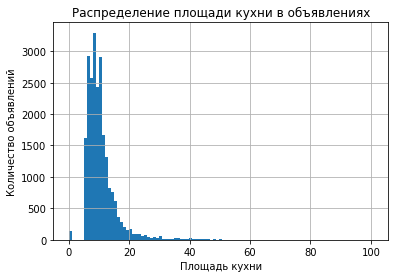

```python
column_describe('kitchen_area')
data['kitchen_area'].hist(bins=101, grid=True)
plt.title('Распределение площади кухни в объявлениях')
plt.xlabel("Площадь кухни")
plt.ylabel("Количество объявлений")
```

```
Количество пропусков в столбце living_area: 0
Тип переменной в столбце living_area: float64
```

```
count    23106.000000
mean        33.972449
std         19.588209
min          2.000000
25%         18.600000
50%         30.000000
75%         42.100000
max        332.000000
Name: living_area, dtype: float64
```

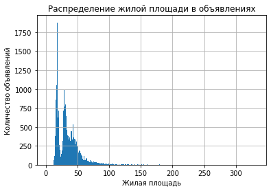

```python
column_describe('living_area')
data['living_area'].hist(bins=331, grid=True)
plt.title('Распределение жилой площади в объявлениях')
plt.xlabel("Жилая площадь")
plt.ylabel("Количество объявлений")
```

```
Количество пропусков в столбце living_area: 0
Тип переменной в столбце living_area: float64
```

```
count    23106.000000
mean        33.972449
std         19.588209
min          2.000000
25%         18.600000
50%         30.000000
75%         42.100000
max        332.000000
Name: living_area, dtype: float64
```

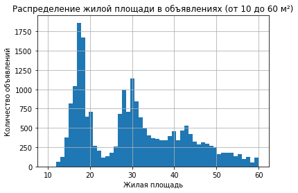

```python
column_describe('living_area')
data['living_area'].hist(bins=51, grid=True, range=(10, 60))
plt.title('Распределение жилой площади в объявлениях (от 10 до 60 м²)')
plt.xlabel("Жилая площадь")
plt.ylabel("Количество объявлений")
```

```
Количество пропусков в столбце total_area: 0
Тип переменной в столбце total_area: float64
```

```
count    23106.000000
mean        59.510561
std         30.592562
min         15.500000
25%         40.200000
50%         52.000000
75%         69.600000
max        517.000000
Name: total_area, dtype: float64
```

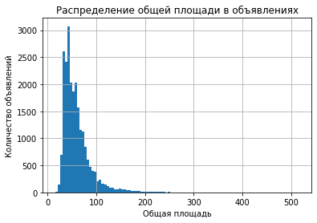

```python
column_describe('total_area')
data['total_area'].hist(bins=100, grid=True)
plt.title('Распределение общей площади в объявлениях')
plt.xlabel("Общая площадь")
plt.ylabel("Количество объявлений")
```

```python
# Проверим распределение параметров по комнатам
data.pivot_table(index='rooms', values=['kitchen_area', 'living_area', 'total_area'], aggfunc=['min', 'median', 'max'])
```

| rooms | min kitchen_area | min living_area | min total_area | median kitchen_area | median living_area | median total_area | max kitchen_area | max living_area | max total_area |
| --- | --- | --- | --- | --- | --- | --- | --- | --- | --- |
| 0 | 0.0 | 2.0 | 15.5 | 0.0 | 17.40 | 25.00 | 0.0 | 25.0 | 28.0 |
| 1 | 5.0 | 12.0 | 20.0 | 9.0 | 17.60 | 36.70 | 58.4 | 60.0 | 190.0 |
| 2 | 5.0 | 12.0 | 20.0 | 8.7 | 30.40 | 53.00 | 62.5 | 99.5 | 160.7 |
| 3 | 5.0 | 12.5 | 40.1 | 9.4 | 45.00 | 72.80 | 100.7 | 170.8 | 263.8 |
| 4 | 5.0 | 21.5 | 48.0 | 11.0 | 63.30 | 98.00 | 75.0 | 248.7 | 470.3 |
| 5 | 5.0 | 23.6 | 40.0 | 15.0 | 89.75 | 141.65 | 65.0 | 182.0 | 365.0 |
| 6 | 5.5 | 51.0 | 87.0 | 18.0 | 117.70 | 180.00 | 56.0 | 300.0 | 460.8 |
| 7 | 5.0 | 57.4 | 125.0 | 18.0 | 132.00 | 203.30 | 53.1 | 332.0 | 517.0 |
| 8 | 5.0 | 107.0 | 150.0 | 23.1 | 157.50 | 232.00 | 40.0 | 176.6 | 347.5 |
| 9 | 11.7 | 157.0 | 235.0 | 13.2 | 160.60 | 292.20 | 41.0 | 225.9 | 398.0 |

**Вывод**

Столбцы kitchen_area и living_area имели пропущенные значения, которые были заменены на медианные по количеству комнат, общей площади и этажу. Столбцы total_area пропусков не имел. Взаимосвязи между пропусками и другими столбцами нет.

К столбцам после замены применена "логическая" чистка.

Все столбцы имеет верный тип данных float64.

### Столбец ceiling_height — высота потолков (м)

```
Количество пропусков в столбце ceiling_height: 8922
Тип переменной в столбце ceiling_height: float64
```

```
count    14184.000000
mean         2.764024
std          1.238467
min          1.000000
25%          2.510000
50%          2.650000
75%          2.800000
max        100.000000
Name: ceiling_height, dtype: float64
```

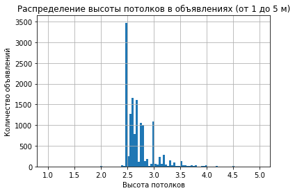

```python
column_describe('ceiling_height')
data['ceiling_height'].hist(bins=101, grid=True, range=(1,5))
plt.title('Распределение высоты потолков в объявлениях (от 1 до 5 м)')
plt.xlabel("Высота потолков")
plt.ylabel("Количество объявлений")
```

Имеется явный провал между 2,8 и 3 метра, т.к. до 2.7 метров стандартное жилье, после 3 метров - элитное. Высота чистового потолка не может быть менее 2 м и более 6 м. Уберем строки, где `ceiling_height` меньше 2 и больше 6 метров.

```python
print('Количество строк, где 2 < ceiling_height < 6 :', len(data.query('ceiling_height < 2 or ceiling_height > 6')))
# Удаление строк
for i in data.query('ceiling_height < 2 or ceiling_height > 6').index:
    data.drop(labels = [i],axis = 0, inplace = True)
# Обнулим индексы
data = data.reset_index(drop=True)
print('Количество строк, где 2 < ceiling_height < 6 :', len(data.query('ceiling_height < 2 or ceiling_height > 6')))
```

```
Количество строк, где 2 < ceiling_height < 6 : 30
Количество строк, где 2 < ceiling_height < 6 : 0
```

Имеются отсутствующие значения (более 38 % данных), которые мы будем заполнять медианными значениями по этажу и этажности дома. Заполнение будем осуществлять по данным параметрам, т.к. высота потолков зависит от типа застройки (например, в сталинках от 3 до 7 этажей с высотой потолков 3,2 м) и этажа (например, только на последних этажах в домах комфорт-класса часто высота потолков более трех метров и отличается от остальных этажей).

```python
print('Количество пропущенных значений ceiling_height:', data['ceiling_height'].isna().sum())
# Заменим отсутствующие значения ceiling_height на медианные по этажу и этажности
data['ceiling_height'] = data['ceiling_height'].fillna(value=0)
for i in data.query('ceiling_height == 0').index:
        floors_total_median = data.loc[i, 'floors_total']
        floor_median = data.loc[i, 'floor']
        data.loc[i, 'ceiling_height'] = data[(data['floors_total'] == floors_total_median) & (data['floor'] == floor_median)& (data['ceiling_height'] != 0)]['ceiling_height'].median()
print('Количество оставшихся пропущенных значений ceiling_height:', len(data.query('ceiling_height == 0')))
```

```
Количество пропущенных значений ceiling_height: 8922
Количество оставшихся пропущенных значений ceiling_height: 0
```

```python
data['ceiling_height'].describe()
```

```
count    23033.000000
mean         2.704247
std          0.226991
min          2.000000
25%          2.550000
50%          2.650000
75%          2.750000
max          5.500000
Name: ceiling_height, dtype: float64
```

**Вывод**

Столбец ceiling_height имеет пропущенные значения (около 38%), которые были заменены на медианные значения по этажу и этажности дома. Были удалены аномальные значения менее 2 и более 6 метров.

Гистограмма ceiling_height рваная имеется явный провал между 2,8 и 3 метра, т.к. до 2.7 метров стандартное жилье, после 3 метров - элитное.Все столбцы имеет верный тип данных float64.

### Столбец days_exposition — сколько дней было размещено объявление (от публикации до снятия)

```
Количество пропусков в столбце days_exposition: 3104
Тип переменной в столбце days_exposition: float64
```

```
count    19972.000000
mean       180.490437
std        219.569626
min          1.000000
25%         45.000000
50%         95.000000
75%        231.000000
max       1580.000000
Name: days_exposition, dtype: float64
```

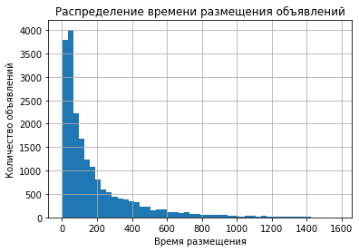

```python
column_describe('days_exposition')
data['days_exposition'].hist(bins=50, grid=True)
plt.title('Распределение времени размещения объявлений')
plt.xlabel("Время размещения")
plt.ylabel("Количество объявлений")
```

```python
print('Количество пропущенных значений days_exposition:', data['days_exposition'].isna().sum())
# Заменим отсутствующие значения days_exposition на 0
data['days_exposition'] = data['days_exposition'].fillna(value=0)
print('Количество оставшихся пропущенных значений days_exposition:', data['days_exposition'].isna().sum())
```

```
Количество пропущенных значений days_exposition: 3104
Количество оставшихся пропущенных значений days_exposition: 0
```

```python
# Изменим тип данных на int64
data['days_exposition'] = data['days_exposition'].astype('int')
```

**Вывод**

### Столбецы airports_nearest, city_сenters_nearest, parks_around_3000, ponds_around_3000, parks_nearest, ponds_nearest

```
Количество пропусков в столбце airports_nearest: 5386
Тип переменной в столбце airports_nearest: float64
```

```
count    17690.000000
mean     28817.588864
std      12644.498190
min          0.000000
25%      18539.000000
50%      26772.000000
75%      37364.000000
max      84869.000000
Name: airports_nearest, dtype: float64
```

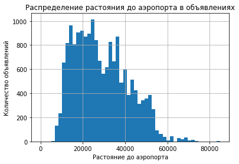

```python
column_describe('airports_nearest')
data['airports_nearest'].hist(bins=50, grid=True)
plt.title('Распределение растояния до аэропорта в объявлениях')
plt.xlabel("Растояние до аэропорта")
plt.ylabel("Количество объявлений")
```

```
Количество пропусков в столбце city_centers_nearest: 5365
Тип переменной в столбце city_centers_nearest: float64
```

```
count    17711.000000
mean     14244.185309
std       8574.405866
min        181.000000
25%       9399.000000
50%      13138.000000
75%      16294.000000
max      65968.000000
Name: city_centers_nearest, dtype: float64
```

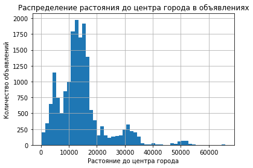

```python
column_describe('city_centers_nearest')
data['city_centers_nearest'].hist(bins=50, grid=True)
plt.title('Распределение растояния до центра города в объявлениях')
plt.xlabel("Растояние до центра города")
plt.ylabel("Количество объявлений")
```

```
Количество пропусков в столбце parks_around_3000: 5364
Тип переменной в столбце parks_around_3000: float64
```

```
count    17712.000000
mean         0.605860
std          0.795416
min          0.000000
25%          0.000000
50%          0.000000
75%          1.000000
max          3.000000
Name: parks_around_3000, dtype: float64
```

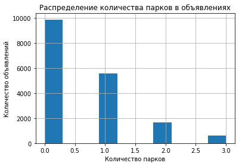

```python
column_describe('parks_around_3000')
data['parks_around_3000'].hist(grid=True)
plt.title('Распределение количества парков в объявлениях')
plt.xlabel("Количество парков")
plt.ylabel("Количество объявлений")
```

```
Количество пропусков в столбце ponds_around_3000: 5364
Тип переменной в столбце ponds_around_3000: float64
```

```
count    17712.000000
mean         0.761009
std          0.932943
min          0.000000
25%          0.000000
50%          0.000000
75%          1.000000
max          3.000000
Name: ponds_around_3000, dtype: float64
```

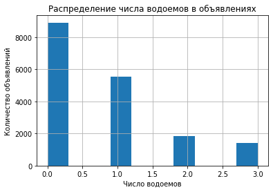

```python
column_describe('ponds_around_3000')
data['ponds_around_3000'].hist(grid=True)
plt.title('Распределение числа водоемов в объявлениях')
plt.xlabel("Число водоемов")
plt.ylabel("Количество объявлений")
```

```
Количество пропусков в столбце parks_nearest: 15226
Тип переменной в столбце parks_nearest: float64
```

```
count    7850.000000
mean      492.338471
std       341.615007
min         1.000000
25%       288.000000
50%       456.000000
75%       613.000000
max      3190.000000
Name: parks_nearest, dtype: float64
```

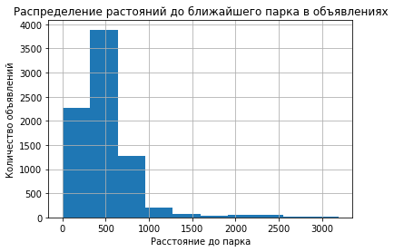

```python
column_describe('parks_nearest')
data['parks_nearest'].hist(grid=True)
plt.title('Распределение растояний до ближайшего парка в объявлениях')
plt.xlabel("Расстояние до парка")
plt.ylabel("Количество объявлений")
```

```
Количество пропусков в столбце ponds_nearest: 14270
Тип переменной в столбце ponds_nearest: float64
```

```
count    8806.000000
mean      520.222916
std       277.444916
min        13.000000
25%       297.000000
50%       504.000000
75%       733.000000
max      1344.000000
Name: ponds_nearest, dtype: float64
```

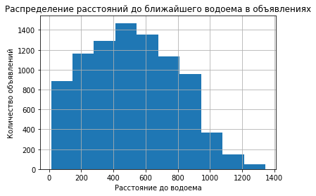

```python
column_describe('ponds_nearest')
data['ponds_nearest'].hist(grid=True)
plt.title('Распределение расстояний до ближайшего водоема в объявлениях')
plt.xlabel("Расстояние до водоема")
plt.ylabel("Количество объявлений")
```

Посмотрим на количество и распределение по населенным пунктам строк, в которых значения отсутствуют во всех 6 столбцах.

```python
data_all_nan = data[(data["parks_nearest"].isnull()) & (data["ponds_nearest"].isnull()) & (data["airports_nearest"].isnull()) & (data["city_centers_nearest"].isnull()) & (data["parks_around_3000"].isnull()) & (data["ponds_around_3000"].isnull())]
data_all_nan
```

|  | total_images | last_price | total_area | first_day_exposition | rooms | ceiling_height | floors_total | living_area | floor | is_apartment | ... | kitchen_area | balcony | locality_name | airports_nearest | city_centers_nearest | parks_around_3000 | parks_nearest | ponds_around_3000 | ponds_nearest | days_exposition |
| --- | --- | --- | --- | --- | --- | --- | --- | --- | --- | --- | --- | --- | --- | --- | --- | --- | --- | --- | --- | --- | --- |
| 4 | 10 | 2890000.0 | 30.40 | 2018-09-10 | 1 | 2.650 | 12 | 14.40 | 5 | NaN | ... | 9.10 | 0 | городской посёлок Янино-1 | NaN | NaN | NaN | NaN | NaN | NaN | 55 |
| 6 | 20 | 2900000.0 | 33.16 | 2018-05-23 | 1 | 2.615 | 27 | 15.43 | 26 | NaN | ... | 8.81 | 0 | посёлок Мурино | NaN | NaN | NaN | NaN | NaN | NaN | 189 |
| 10 | 10 | 3890000.0 | 54.00 | 2016-06-30 | 2 | 2.550 | 5 | 30.00 | 5 | NaN | ... | 9.00 | 0 | Сертолово | NaN | NaN | NaN | NaN | NaN | NaN | 90 |
| 20 | 20 | 5000000.0 | 58.00 | 2017-04-24 | 2 | 2.750 | 25 | 30.00 | 15 | NaN | ... | 11.00 | 2 | деревня Кудрово | NaN | NaN | NaN | NaN | NaN | NaN | 60 |
| 28 | 12 | 2200000.0 | 32.80 | 2018-02-19 | 1 | 2.550 | 9 | 17.00 | 2 | NaN | ... | 7.30 | 0 | Коммунар | NaN | NaN | NaN | NaN | NaN | NaN | 63 |
| ... | ... | ... | ... | ... | ... | ... | ... | ... | ... | ... | ... | ... | ... | ... | ... | ... | ... | ... | ... | ... | ... |
| 23060 | 16 | 2100000.0 | 62.80 | 2018-09-18 | 4 | 2.500 | 5 | 45.50 | 3 | NaN | ... | 5.50 | 0 | посёлок Дзержинского | NaN | NaN | NaN | NaN | NaN | NaN | 0 |
| 23069 | 2 | 1350000.0 | 30.00 | 2017-07-07 | 1 | 2.555 | 5 | 17.50 | 4 | NaN | ... | 6.00 | 0 | Тихвин | NaN | NaN | NaN | NaN | NaN | NaN | 413 |
| 23072 | 14 | 3100000.0 | 59.00 | 2018-01-15 | 3 | 2.555 | 5 | 38.00 | 4 | NaN | ... | 8.50 | 0 | Тосно | NaN | NaN | NaN | NaN | NaN | NaN | 45 |
| 23073 | 18 | 2500000.0 | 56.70 | 2018-02-11 | 2 | 2.750 | 3 | 29.70 | 1 | NaN | ... | 8.80 | 0 | село Рождествено | NaN | NaN | NaN | NaN | NaN | NaN | 0 |
| 23075 | 4 | 1350000.0 | 32.30 | 2017-07-21 | 1 | 2.500 | 5 | 12.30 | 1 | NaN | ... | 9.00 | 0 | посёлок Новый Учхоз | NaN | NaN | NaN | NaN | NaN | NaN | 0 |

5364 rows × 22 columns

```python
# Посмотрим на распределение отсутствующих значений по городам
print('Количество уникальных наименований населенных пунктов с отсутствующими значениями во всех 6 столбцах:', len(data_all_nan['locality_name'].value_counts()))
data_all_nan['locality_name'].value_counts().head(25)
```

```
Количество уникальных наименований населенных пунктов с отсутствующими значениями во всех 6 столбцах: 309
```

```
посёлок Мурино               523
Всеволожск                   392
Гатчина                      297
деревня Кудрово              291
Выборг                       234
Кудрово                      170
деревня Новое Девяткино      142
Сертолово                    141
Кириши                       124
Сланцы                       112
Волхов                       109
посёлок Бугры                108
Кингисепп                    104
Тосно                        103
Коммунар                      87
Сосновый Бор                  84
Никольское                    84
Кировск                       81
Отрадное                      79
Приозерск                     65
городской посёлок Янино-1     65
деревня Старая                61
Шлиссельбург                  57
Санкт-Петербург               55
Луга                          53
Name: locality_name, dtype: int64
```

```python
# Посмотрим сколько всего уникальных наименований населенных пунктов
print('Количество уникальных наименований населенных пунктов:', len(data['locality_name'].value_counts()))
```

```
Количество уникальных наименований населенных пунктов: 328
```

В большей части населенных пунктов (94 %) имеются пропуски сразу во всех столбцах, включая Санкт-Петербург.

```python
# Посмотрим в каких 19 населенных пунктах есть информация хотя бы в одном из 6 столбцов
good_locality_name = []
for i in data['locality_name'].value_counts().index:
    if i not in list(data_all_nan['locality_name'].value_counts().index):
        good_locality_name.append(i)
good_locality_name
```

```
['Пушкин',
 'посёлок Парголово',
 'Петергоф',
 'Сестрорецк',
 'посёлок Металлострой',
 'посёлок Стрельна',
 'Павловск',
 'Зеленогорск',
 'посёлок Понтонный',
 'посёлок Сапёрный',
 'посёлок Молодёжное',
 'посёлок Репино',
 'посёлок Лисий Нос',
 'посёлок Песочный',
 'посёлок Александровская',
 'посёлок Усть-Ижора',
 'посёлок Левашово',
 'посёлок Петро-Славянка',
 'посёлок Белоостров']
```

```python
# Определим количество объявлений для каждого населенного пункта, в котором информация есть хотя бы в одном столбце
for i in good_locality_name:
    print(f'Для населенного пункта {i} всего имеется {len(data[data["locality_name"] == i])} объявлений.')
```

```
Для населенного пункта Пушкин всего имеется 365 объявлений.
Для населенного пункта посёлок Парголово всего имеется 318 объявлений.
Для населенного пункта Петергоф всего имеется 200 объявлений.
Для населенного пункта Сестрорецк всего имеется 178 объявлений.
Для населенного пункта посёлок Металлострой всего имеется 66 объявлений.
Для населенного пункта посёлок Стрельна всего имеется 41 объявлений.
Для населенного пункта Павловск всего имеется 38 объявлений.
Для населенного пункта Зеленогорск всего имеется 23 объявлений.
Для населенного пункта посёлок Понтонный всего имеется 20 объявлений.
Для населенного пункта посёлок Сапёрный всего имеется 6 объявлений.
Для населенного пункта посёлок Молодёжное всего имеется 5 объявлений.
Для населенного пункта посёлок Репино всего имеется 4 объявлений.
Для населенного пункта посёлок Лисий Нос всего имеется 3 объявлений.
Для населенного пункта посёлок Песочный всего имеется 2 объявлений.
Для населенного пункта посёлок Александровская всего имеется 2 объявлений.
Для населенного пункта посёлок Усть-Ижора всего имеется 2 объявлений.
Для населенного пункта посёлок Левашово всего имеется 1 объявлений.
Для населенного пункта посёлок Петро-Славянка всего имеется 1 объявлений.
Для населенного пункта посёлок Белоостров всего имеется 1 объявлений.
```

```python
# Посмотрим на распределение значений по столбцам
data_all_nan.describe()
```

|  | total_images | last_price | total_area | rooms | ceiling_height | floors_total | living_area | floor | kitchen_area | balcony | airports_nearest | city_centers_nearest | parks_around_3000 | parks_nearest | ponds_around_3000 | ponds_nearest | days_exposition |
| --- | --- | --- | --- | --- | --- | --- | --- | --- | --- | --- | --- | --- | --- | --- | --- | --- | --- |
| count | 5364.000000 | 5.364000e+03 | 5364.000000 | 5364.000000 | 5356.000000 | 5364.000000 | 5364.000000 | 5364.000000 | 5364.000000 | 5364.000000 | 0.0 | 0.0 | 0.0 | 0.0 | 0.0 | 0.0 | 5364.000000 |
| mean | 9.282625 | 3.117359e+06 | 50.677218 | 1.856078 | 2.648836 | 8.975391 | 28.893827 | 5.043438 | 9.024241 | 0.619687 | NaN | NaN | NaN | NaN | NaN | NaN | 148.165362 |
| std | 5.433056 | 2.161625e+06 | 18.643214 | 0.872529 | 0.162199 | 6.456740 | 12.491420 | 4.538416 | 3.601764 | 0.946269 | NaN | NaN | NaN | NaN | NaN | NaN | 200.731770 |
| min | 0.000000 | 4.300000e+05 | 19.500000 | 0.000000 | 2.000000 | 1.000000 | 2.000000 | 1.000000 | 0.000000 | 0.000000 | NaN | NaN | NaN | NaN | NaN | NaN | 0.000000 |
| 25% | 5.000000 | 2.000000e+06 | 36.852500 | 1.000000 | 2.550000 | 5.000000 | 17.800000 | 2.000000 | 7.000000 | 0.000000 | NaN | NaN | NaN | NaN | NaN | NaN | 23.000000 |
| 50% | 9.000000 | 2.800000e+06 | 46.800000 | 2.000000 | 2.600000 | 5.000000 | 28.100000 | 4.000000 | 8.500000 | 0.000000 | NaN | NaN | NaN | NaN | NaN | NaN | 66.500000 |
| 75% | 13.000000 | 3.700000e+06 | 60.000000 | 2.000000 | 2.720000 | 12.000000 | 36.000000 | 6.000000 | 10.192500 | 1.000000 | NaN | NaN | NaN | NaN | NaN | NaN | 189.000000 |
| max | 39.000000 | 4.450000e+07 | 364.700000 | 7.000000 | 5.000000 | 28.000000 | 147.200000 | 27.000000 | 63.000000 | 5.000000 | NaN | NaN | NaN | NaN | NaN | NaN | 1580.000000 |

Для всех отсутствующих значений столбца `ponds_around_3000` данные отсутствуют и в столбцах `parks_around_3000`, `city_centers_nearest`.

```python
# Посмотрим на строку, где для отсутствующего значения city_centers_nearest имеются значения в ponds_around_3000 и parks_around_3000
data.query('city_centers_nearest.isnull() == True and parks_around_3000.isnull() == False')
```

[output not shown]

1 rows × 22 columns

```python
# Заменим отсутствующее значения не медианное по locality_name и airports_nearest
data.loc[19504, 'city_centers_nearest'] = data.query('locality_name == "Пушкин" and airports_nearest >15500 and airports_nearest < 15550')['city_centers_nearest'].median()
```

Посмотрим на отсутствующие значения `airports_nearest` для которых имеются значения в столбцах `ponds_around_3000`, `parks_around_3000`, `city_centers_nearest`.

```python
data.query('airports_nearest.isnull() == True and city_centers_nearest.isnull() == False')
```

|  | total_images | last_price | total_area | first_day_exposition | rooms | ceiling_height | floors_total | living_area | floor | is_apartment | ... | kitchen_area | balcony | locality_name | airports_nearest | city_centers_nearest | parks_around_3000 | parks_nearest | ponds_around_3000 | ponds_nearest | days_exposition |
| --- | --- | --- | --- | --- | --- | --- | --- | --- | --- | --- | --- | --- | --- | --- | --- | --- | --- | --- | --- | --- | --- |
| 709 | 18 | 18700000.0 | 109.7 | 2018-02-03 | 3 | 2.750 | 21 | 57.20 | 13 | NaN | ... | 15.3 | 1 | Санкт-Петербург | NaN | 13355.0 | 1.0 | 735.0 | 0.0 | NaN | 112 |
| 945 | 8 | 25897000.0 | 149.0 | 2018-03-26 | 4 | 2.740 | 7 | 79.30 | 6 | NaN | ... | 19.2 | 0 | Санкт-Петербург | NaN | 9734.0 | 2.0 | 469.0 | 3.0 | 263.0 | 90 |
| 2351 | 17 | 9500000.0 | 67.4 | 2017-04-15 | 2 | 2.800 | 23 | 37.60 | 4 | NaN | ... | 12.0 | 0 | Санкт-Петербург | NaN | 13355.0 | 1.0 | 735.0 | 0.0 | NaN | 56 |
| 7330 | 16 | 43500000.0 | 245.8 | 2015-12-17 | 3 | 4.450 | 7 | 170.80 | 7 | True | ... | 25.0 | 1 | Санкт-Петербург | NaN | 5735.0 | 2.0 | 110.0 | 0.0 | NaN | 1067 |
| 7351 | 10 | 6900000.0 | 50.0 | 2016-03-17 | 1 | 2.800 | 23 | 20.00 | 12 | NaN | ... | 10.0 | 0 | Санкт-Петербург | NaN | 13355.0 | 1.0 | 735.0 | 0.0 | NaN | 317 |
| 8405 | 0 | 8000000.0 | 48.9 | 2018-02-23 | 1 | 3.120 | 6 | 19.05 | 4 | NaN | ... | 10.8 | 0 | Санкт-Петербург | NaN | 5735.0 | 2.0 | 110.0 | 0.0 | NaN | 60 |
| 8822 | 5 | 13000000.0 | 71.8 | 2017-09-12 | 2 | 2.750 | 10 | 32.50 | 5 | NaN | ... | 18.9 | 2 | Санкт-Петербург | NaN | 9734.0 | 2.0 | 469.0 | 3.0 | 263.0 | 156 |
| 9632 | 11 | 5300000.0 | 51.0 | 2018-01-10 | 2 | 2.555 | 5 | 22.60 | 4 | NaN | ... | 15.8 | 0 | Санкт-Петербург | NaN | 4892.0 | 0.0 | NaN | 2.0 | 369.0 | 13 |
| 10404 | 9 | 3400000.0 | 46.0 | 2018-09-01 | 2 | 2.600 | 5 | 28.00 | 5 | NaN | ... | 6.7 | 0 | Санкт-Петербург | NaN | 21377.0 | 0.0 | NaN | 0.0 | NaN | 106 |
| 11153 | 5 | 4000000.0 | 45.0 | 2016-09-07 | 2 | 2.550 | 5 | 28.20 | 3 | NaN | ... | 6.0 | 0 | Санкт-Петербург | NaN | 11835.0 | 1.0 | 267.0 | 1.0 | 601.0 | 224 |
| 11164 | 9 | 12900000.0 | 73.5 | 2017-09-12 | 2 | 2.750 | 10 | 32.90 | 5 | NaN | ... | 18.5 | 2 | Санкт-Петербург | NaN | 9734.0 | 2.0 | 469.0 | 3.0 | 263.0 | 156 |
| 12768 | 13 | 27000000.0 | 116.0 | 2018-02-01 | 2 | 3.400 | 7 | 78.90 | 2 | NaN | ... | 11.0 | 1 | Санкт-Петербург | NaN | 5735.0 | 2.0 | 110.0 | 0.0 | NaN | 0 |
| 13911 | 20 | 21500000.0 | 107.0 | 2017-10-23 | 2 | 2.700 | 25 | 55.00 | 19 | NaN | ... | 13.0 | 0 | Санкт-Петербург | NaN | 9734.0 | 2.0 | 469.0 | 3.0 | 263.0 | 546 |
| 16059 | 7 | 11900000.0 | 101.0 | 2017-04-15 | 3 | 2.750 | 19 | 56.00 | 9 | NaN | ... | 15.0 | 0 | Санкт-Петербург | NaN | 13355.0 | 1.0 | 735.0 | 0.0 | NaN | 21 |
| 16403 | 20 | 9000000.0 | 48.0 | 2017-02-19 | 1 | 2.800 | 16 | 19.00 | 4 | False | ... | 15.0 | 2 | Санкт-Петербург | NaN | 9734.0 | 2.0 | 469.0 | 3.0 | 263.0 | 182 |
| 16503 | 11 | 6680000.0 | 46.0 | 2018-11-21 | 1 | 3.000 | 23 | 20.00 | 9 | NaN | ... | 10.0 | 2 | Санкт-Петербург | NaN | 13355.0 | 1.0 | 735.0 | 0.0 | NaN | 20 |
| 17757 | 20 | 9500000.0 | 70.2 | 2017-04-15 | 2 | 2.800 | 23 | 40.00 | 10 | NaN | ... | 12.0 | 0 | Санкт-Петербург | NaN | 13355.0 | 1.0 | 735.0 | 0.0 | NaN | 118 |
| 18084 | 10 | 12500000.0 | 100.0 | 2016-08-17 | 3 | 2.750 | 19 | 58.00 | 3 | NaN | ... | 15.5 | 0 | Санкт-Петербург | NaN | 13355.0 | 1.0 | 735.0 | 0.0 | NaN | 161 |
| 20531 | 1 | 3650000.0 | 48.8 | 2017-06-24 | 4 | 2.500 | 5 | 37.00 | 1 | NaN | ... | 5.2 | 0 | Санкт-Петербург | NaN | 11246.0 | 0.0 | NaN | 0.0 | NaN | 174 |
| 21201 | 20 | 16500000.0 | 82.7 | 2018-10-31 | 2 | 2.910 | 25 | 45.70 | 9 | NaN | ... | 17.2 | 2 | Санкт-Петербург | NaN | 9734.0 | 2.0 | 469.0 | 3.0 | 263.0 | 0 |
| 22186 | 8 | 5600000.0 | 47.0 | 2017-09-27 | 1 | 2.600 | 23 | 21.00 | 7 | NaN | ... | 11.0 | 1 | Санкт-Петербург | NaN | 13355.0 | 1.0 | 735.0 | 0.0 | NaN | 10 |
| 22510 | 0 | 3500000.0 | 41.3 | 2018-01-11 | 3 | 2.550 | 5 | 29.50 | 1 | NaN | ... | 6.0 | 0 | Санкт-Петербург | NaN | 11246.0 | 0.0 | NaN | 0.0 | NaN | 23 |

22 rows × 22 columns

Все эти объявления находятся в определенных местах Санкт-Петербурга. Некоторые объявления находятся в одних и тех же локациях, т.к. информация в других столбцах одинаковая. Так как таких объявлений мало - удалим их.

```python
print('Размер data до удаления:', data.shape)
# Удалим значение
for i in data.query('airports_nearest.isnull() == True and city_centers_nearest.isnull() == False').index:
    data.drop(labels = [i],axis = 0, inplace = True)
# Обнулим индексы
data = data.reset_index(drop=True)
# Проверим размер после удаления
print('Размер data после удаления:', data.shape)
```

```
Размер data до удаления: (23076, 22)
Размер data после удаления: (23054, 22)
```

Столбцы `parks_nearest` и `ponds_nearest` имеют близкое количество отсутствующих значений.

```python
# Посмотрим на количество строк с отсутствующими значениями сразу в двух столбцах
data.query('parks_nearest.isnull() == True and ponds_nearest.isnull() == True')
```

|  | total_images | last_price | total_area | first_day_exposition | rooms | ceiling_height | floors_total | living_area | floor | is_apartment | ... | kitchen_area | balcony | locality_name | airports_nearest | city_centers_nearest | parks_around_3000 | parks_nearest | ponds_around_3000 | ponds_nearest | days_exposition |
| --- | --- | --- | --- | --- | --- | --- | --- | --- | --- | --- | --- | --- | --- | --- | --- | --- | --- | --- | --- | --- | --- |
| 1 | 7 | 3350000.0 | 40.40 | 2018-12-04 | 1 | 2.715 | 11 | 18.60 | 1 | NaN | ... | 11.00 | 2 | посёлок Шушары | 12817.0 | 18603.0 | 0.0 | NaN | 0.0 | NaN | 81 |
| 4 | 10 | 2890000.0 | 30.40 | 2018-09-10 | 1 | 2.650 | 12 | 14.40 | 5 | NaN | ... | 9.10 | 0 | городской посёлок Янино-1 | NaN | NaN | NaN | NaN | NaN | NaN | 55 |
| 5 | 5 | 7915000.0 | 71.60 | 2019-04-18 | 2 | 2.700 | 24 | 34.00 | 22 | NaN | ... | 18.90 | 2 | Санкт-Петербург | 23982.0 | 11634.0 | 0.0 | NaN | 0.0 | NaN | 0 |
| 6 | 20 | 2900000.0 | 33.16 | 2018-05-23 | 1 | 2.615 | 27 | 15.43 | 26 | NaN | ... | 8.81 | 0 | посёлок Мурино | NaN | NaN | NaN | NaN | NaN | NaN | 189 |
| 7 | 18 | 5400000.0 | 61.00 | 2017-02-26 | 3 | 2.500 | 9 | 43.60 | 7 | NaN | ... | 6.50 | 2 | Санкт-Петербург | 50898.0 | 15008.0 | 0.0 | NaN | 0.0 | NaN | 289 |
| ... | ... | ... | ... | ... | ... | ... | ... | ... | ... | ... | ... | ... | ... | ... | ... | ... | ... | ... | ... | ... | ... |
| 23043 | 19 | 9200000.0 | 101.00 | 2019-04-01 | 3 | 3.050 | 15 | 63.00 | 12 | NaN | ... | 15.00 | 0 | Санкт-Петербург | 15632.0 | 14428.0 | 0.0 | NaN | 0.0 | NaN | 23 |
| 23047 | 2 | 1350000.0 | 30.00 | 2017-07-07 | 1 | 2.555 | 5 | 17.50 | 4 | NaN | ... | 6.00 | 0 | Тихвин | NaN | NaN | NaN | NaN | NaN | NaN | 413 |
| 23050 | 14 | 3100000.0 | 59.00 | 2018-01-15 | 3 | 2.555 | 5 | 38.00 | 4 | NaN | ... | 8.50 | 0 | Тосно | NaN | NaN | NaN | NaN | NaN | NaN | 45 |
| 23051 | 18 | 2500000.0 | 56.70 | 2018-02-11 | 2 | 2.750 | 3 | 29.70 | 1 | NaN | ... | 8.80 | 0 | село Рождествено | NaN | NaN | NaN | NaN | NaN | NaN | 0 |
| 23053 | 4 | 1350000.0 | 32.30 | 2017-07-21 | 1 | 2.500 | 5 | 12.30 | 1 | NaN | ... | 9.00 | 0 | посёлок Новый Учхоз | NaN | NaN | NaN | NaN | NaN | NaN | 0 |

11068 rows × 22 columns

Посмотрим на распределение `parks_around_3000`среди отсутствующих значений столбца `parks_nearest`.

```python
data.query('parks_nearest.isnull() == True')['parks_around_3000'].value_counts()
```

```
0.0    9858
Name: parks_around_3000, dtype: int64
```

```python
# Посмотрим на количество и распределение значений parks_nearest более 3000 м
data.query('parks_nearest >= 3000')['parks_nearest'].value_counts()
```

```
3190.0    2
3064.0    1
3013.0    1
Name: parks_nearest, dtype: int64
```

Скорее всего значения отсутствуют, т.к. в радиусе 3000 м парки отсутствуют или отсутствует информация об их количестве.

Посмотрим на распределение `ponds_around_3000`среди отсутствующих значений столбца `ponds_nearest`.

```python
data.query('ponds_nearest.isnull() == True')['ponds_around_3000'].value_counts()
```

```
0.0    8892
Name: ponds_around_3000, dtype: int64
```

```python
# Посмотрим на максимальное значений parks_nearest
data['ponds_nearest'].max()
```

```
1344.0
```

Скорее всего, значения отсутствуют, т.к. в радиусе 3000 м водоемы отсутствуют или отсутствует информация об их количестве.

**Вывод**

В столбцах `airports_nearest`, `city_сenters_nearest`, `parks_around_3000`, `ponds_around_3000` отсутствующие значения взаимосвязаны. Почти всегда если значение отсутствует в одном столбце, то оно отсутствует и в других. Строки с отсутствующими значениями `airports_nearest` при имеющихся данных в столбцах `city_сenters_nearest`, `parks_around_3000`, `ponds_around_3000` для Санкт-Петербурга были удалены.

Отсутствующие значения в столбце `parks_nearest` связаны со значениями в столбце `parks_around_3000`. Если в радиусе 3000 м парки отсутствуют или отсутствует информация об их количестве, то отсутствует информация в столбце `parks_nearest`.

Отсутствующие значения в столбце `ponds_nearest` связаны со значениями в столбце `ponds_around_3000`. Если в радиусе 3000 м водоемы отсутствуют или отсутствует информация об их количестве, то отсутствует информация в столбце `ponds_nearest`.

C данными в этих столбцах не имеет смысла производить манипуляции (удаление или замена), чтобы можно было их визуализировать. Тип данных изменять не имеет смысла, т.к. отсутствующие значения (NaN) - float.

```python
# Попробуем найти явные дубликаты в таблице
print(f'Всего имеется {data.duplicated().sum()} явных дубликатов.')
```

```
Всего имеется 0 явных дубликатов.
```

## Расчёты и добавление результатов в таблицу

По условию задания необходимо посчитать и добавить в таблицу:

- цену квадратного метра;
- день недели, месяц и год публикации объявления;
- этаж квартиры (первый, последний, другой);
- соотношение жилой и общей площади, отношение площади кухни и общей площади.

```python
# Добавим столбец со стоимостью квадратного метра
data['price_per_meter'] = round(data['last_price'] / data['total_area'], 2)
data.head()
```

|  | total_images | last_price | total_area | first_day_exposition | rooms | ceiling_height | floors_total | living_area | floor | is_apartment | ... | balcony | locality_name | airports_nearest | city_centers_nearest | parks_around_3000 | parks_nearest | ponds_around_3000 | ponds_nearest | days_exposition | price_per_meter |
| --- | --- | --- | --- | --- | --- | --- | --- | --- | --- | --- | --- | --- | --- | --- | --- | --- | --- | --- | --- | --- | --- |
| 0 | 20 | 13000000.0 | 108.0 | 2019-03-07 | 3 | 2.700 | 16 | 51.0 | 8 | NaN | ... | 0 | Санкт-Петербург | 18863.0 | 16028.0 | 1.0 | 482.0 | 2.0 | 755.0 | 0 | 120370.37 |
| 1 | 7 | 3350000.0 | 40.4 | 2018-12-04 | 1 | 2.715 | 11 | 18.6 | 1 | NaN | ... | 2 | посёлок Шушары | 12817.0 | 18603.0 | 0.0 | NaN | 0.0 | NaN | 81 | 82920.79 |
| 2 | 10 | 5196000.0 | 56.0 | 2015-08-20 | 2 | 2.555 | 5 | 34.3 | 4 | NaN | ... | 0 | Санкт-Петербург | 21741.0 | 13933.0 | 1.0 | 90.0 | 2.0 | 574.0 | 558 | 92785.71 |
| 3 | 2 | 10000000.0 | 100.0 | 2018-06-19 | 2 | 3.030 | 14 | 32.0 | 13 | NaN | ... | 0 | Санкт-Петербург | 31856.0 | 8098.0 | 2.0 | 112.0 | 1.0 | 48.0 | 121 | 100000.00 |
| 4 | 10 | 2890000.0 | 30.4 | 2018-09-10 | 1 | 2.650 | 12 | 14.4 | 5 | NaN | ... | 0 | городской посёлок Янино-1 | NaN | NaN | NaN | NaN | NaN | NaN | 55 | 95065.79 |

5 rows × 23 columns

```python
# Добавим столбецы с днем недели, месяцем и годом публикации объявления
data['exposition_day_of_week'] = data["first_day_exposition"].dt.dayofweek
data['exposition_month'] = data["first_day_exposition"].dt.month
data['exposition_year'] = data["first_day_exposition"].dt.year
data.head()
```

|  | total_images | last_price | total_area | first_day_exposition | rooms | ceiling_height | floors_total | living_area | floor | is_apartment | ... | city_centers_nearest | parks_around_3000 | parks_nearest | ponds_around_3000 | ponds_nearest | days_exposition | price_per_meter | exposition_day_of_week | exposition_month | exposition_year |
| --- | --- | --- | --- | --- | --- | --- | --- | --- | --- | --- | --- | --- | --- | --- | --- | --- | --- | --- | --- | --- | --- |
| 0 | 20 | 13000000.0 | 108.0 | 2019-03-07 | 3 | 2.700 | 16 | 51.0 | 8 | NaN | ... | 16028.0 | 1.0 | 482.0 | 2.0 | 755.0 | 0 | 120370.37 | 3 | 3 | 2019 |
| 1 | 7 | 3350000.0 | 40.4 | 2018-12-04 | 1 | 2.715 | 11 | 18.6 | 1 | NaN | ... | 18603.0 | 0.0 | NaN | 0.0 | NaN | 81 | 82920.79 | 1 | 12 | 2018 |
| 2 | 10 | 5196000.0 | 56.0 | 2015-08-20 | 2 | 2.555 | 5 | 34.3 | 4 | NaN | ... | 13933.0 | 1.0 | 90.0 | 2.0 | 574.0 | 558 | 92785.71 | 3 | 8 | 2015 |
| 3 | 2 | 10000000.0 | 100.0 | 2018-06-19 | 2 | 3.030 | 14 | 32.0 | 13 | NaN | ... | 8098.0 | 2.0 | 112.0 | 1.0 | 48.0 | 121 | 100000.00 | 1 | 6 | 2018 |
| 4 | 10 | 2890000.0 | 30.4 | 2018-09-10 | 1 | 2.650 | 12 | 14.4 | 5 | NaN | ... | NaN | NaN | NaN | NaN | NaN | 55 | 95065.79 | 0 | 9 | 2018 |

5 rows × 26 columns

```python
# Добавим категорию этажа (первый, последний, другой)
data['floor_category'] = ['другой'] * len(data)
data.loc[data['floor'] == 1, 'floor_category'] = 'первый'
data.loc[data['floor'] == data['floors_total'], 'floor_category'] = 'последний'
data.head()
```

|  | total_images | last_price | total_area | first_day_exposition | rooms | ceiling_height | floors_total | living_area | floor | is_apartment | ... | parks_around_3000 | parks_nearest | ponds_around_3000 | ponds_nearest | days_exposition | price_per_meter | exposition_day_of_week | exposition_month | exposition_year | floor_category |
| --- | --- | --- | --- | --- | --- | --- | --- | --- | --- | --- | --- | --- | --- | --- | --- | --- | --- | --- | --- | --- | --- |
| 0 | 20 | 13000000.0 | 108.0 | 2019-03-07 | 3 | 2.700 | 16 | 51.0 | 8 | NaN | ... | 1.0 | 482.0 | 2.0 | 755.0 | 0 | 120370.37 | 3 | 3 | 2019 | другой |
| 1 | 7 | 3350000.0 | 40.4 | 2018-12-04 | 1 | 2.715 | 11 | 18.6 | 1 | NaN | ... | 0.0 | NaN | 0.0 | NaN | 81 | 82920.79 | 1 | 12 | 2018 | первый |
| 2 | 10 | 5196000.0 | 56.0 | 2015-08-20 | 2 | 2.555 | 5 | 34.3 | 4 | NaN | ... | 1.0 | 90.0 | 2.0 | 574.0 | 558 | 92785.71 | 3 | 8 | 2015 | другой |
| 3 | 2 | 10000000.0 | 100.0 | 2018-06-19 | 2 | 3.030 | 14 | 32.0 | 13 | NaN | ... | 2.0 | 112.0 | 1.0 | 48.0 | 121 | 100000.00 | 1 | 6 | 2018 | другой |
| 4 | 10 | 2890000.0 | 30.4 | 2018-09-10 | 1 | 2.650 | 12 | 14.4 | 5 | NaN | ... | NaN | NaN | NaN | NaN | 55 | 95065.79 | 0 | 9 | 2018 | другой |

5 rows × 27 columns

```python
# Добавим столбецы с отношениями площадей кухни и жилой к общей площади
data['kitchen_to_total'] = round(data['kitchen_area'] / data['total_area'], 3)
data['living_to_total'] = round(data['living_area'] / data['total_area'], 3)
data.head()
```

|  | total_images | last_price | total_area | first_day_exposition | rooms | ceiling_height | floors_total | living_area | floor | is_apartment | ... | ponds_around_3000 | ponds_nearest | days_exposition | price_per_meter | exposition_day_of_week | exposition_month | exposition_year | floor_category | kitchen_to_total | living_to_total |
| --- | --- | --- | --- | --- | --- | --- | --- | --- | --- | --- | --- | --- | --- | --- | --- | --- | --- | --- | --- | --- | --- |
| 0 | 20 | 13000000.0 | 108.0 | 2019-03-07 | 3 | 2.700 | 16 | 51.0 | 8 | NaN | ... | 2.0 | 755.0 | 0 | 120370.37 | 3 | 3 | 2019 | другой | 0.231 | 0.472 |
| 1 | 7 | 3350000.0 | 40.4 | 2018-12-04 | 1 | 2.715 | 11 | 18.6 | 1 | NaN | ... | 0.0 | NaN | 81 | 82920.79 | 1 | 12 | 2018 | первый | 0.272 | 0.460 |
| 2 | 10 | 5196000.0 | 56.0 | 2015-08-20 | 2 | 2.555 | 5 | 34.3 | 4 | NaN | ... | 2.0 | 574.0 | 558 | 92785.71 | 3 | 8 | 2015 | другой | 0.148 | 0.612 |
| 3 | 2 | 10000000.0 | 100.0 | 2018-06-19 | 2 | 3.030 | 14 | 32.0 | 13 | NaN | ... | 1.0 | 48.0 | 121 | 100000.00 | 1 | 6 | 2018 | другой | 0.410 | 0.320 |
| 4 | 10 | 2890000.0 | 30.4 | 2018-09-10 | 1 | 2.650 | 12 | 14.4 | 5 | NaN | ... | NaN | NaN | 55 | 95065.79 | 0 | 9 | 2018 | другой | 0.299 | 0.474 |

5 rows × 29 columns

**Вывод**

Все необходимые для анализа столбцы введены. Можно переходить к исследовательскому анализу данных.

## Исследовательский анализ данных

### Изучите следующие параметры: площадь, цена, число комнат, высота потолков. Постройте гистограммы для каждого параметра.

Построим гистограммы и выведем статистику для следующих параметров: площадь, цена, число комнат, высота потолков.

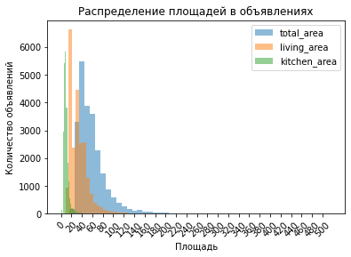

```python
data['total_area'].plot.hist(alpha = 0.5 , bins = 50)
data['living_area'].plot.hist(alpha = 0.5, bins = 50)
data['kitchen_area'].plot.hist(alpha = 0.5, bins = 50)
plt.title('Распределение площадей в объявлениях')
plt.xlabel("Площадь")
plt.ylabel("Количество объявлений")
plt.xticks(np.arange(0, data['total_area'].max(), 20))
plt.xticks(rotation = 45)
plt.legend()
plt.show()
```

```python
for i in ['kitchen_area', 'living_area', 'total_area']:
    print(f'Описательная статистика по столбцу {i}')
    display(data[i].describe())
```

```
Описательная статистика по столбцу kitchen_area
```

```
count    23054.000000
mean        10.278962
std          5.288152
min          0.000000
25%          7.000000
50%          9.000000
75%         11.650000
max        100.700000
Name: kitchen_area, dtype: float64
```

```
Описательная статистика по столбцу living_area
```

```
count    23054.000000
mean        33.966446
std         19.574737
min          2.000000
25%         18.600000
50%         30.000000
75%         42.100000
max        332.000000
Name: living_area, dtype: float64
```

```
Описательная статистика по столбцу total_area
```

```
count    23054.000000
mean        59.499711
std         30.578279
min         15.500000
25%         40.137500
50%         52.000000
75%         69.522500
max        517.000000
Name: total_area, dtype: float64
```

В выборке собраны объявления с различными вариантами площадей. `Total_area` плавнее, чем `kitchen_area` и `living_area`. Это связано с тем, что они являются составными частями total_area. Подробно данные столбцы анализировались на этапе предобработки данных.

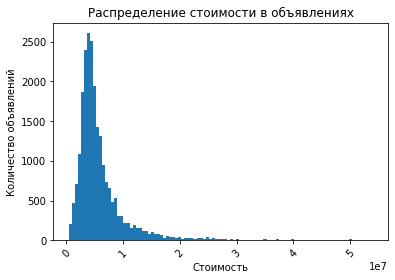

```python
data['last_price'].plot.hist(bins = 100)
plt.title('Распределение стоимости в объявлениях')
plt.xlabel("Стоимость")
plt.ylabel("Количество объявлений")
plt.xticks(np.arange(0, data['last_price'].max(), 10000000))
plt.xticks(rotation = 45)
plt.show()
```

```python
print('Описательная статистика по столбцу last_price')
data['last_price'].describe()
```

```
Описательная статистика по столбцу last_price
```

```
count    2.305400e+04
mean     6.039537e+06
std      5.060892e+06
min      4.300000e+05
25%      3.450000e+06
50%      4.650000e+06
75%      6.750000e+06
max      5.400000e+07
Name: last_price, dtype: float64
```

В подборке имеются объявления со стоимостью от 430 тыс. до 54 млн. По графику и взаимному расположению среднего и медианного значений видно, что пребладают малые значения цен на жилье. Но также имеется небольшое количество дорогой недвижимости.

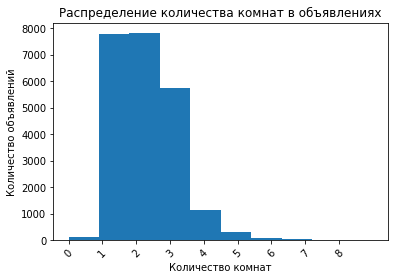

```python
data['rooms'].plot.hist(bins = 10)
plt.title('Распределение количества комнат в объявлениях')
plt.xlabel("Количество комнат")
plt.ylabel("Количество объявлений")
plt.xticks(np.arange(0, data['rooms'].max(), 1))
plt.xticks(rotation = 45)
plt.show()
```

```python
print('Описательная статистика по столбцу rooms')
data['rooms'].describe()
```

```
Описательная статистика по столбцу rooms
```

```
count    23054.000000
mean         2.066843
std          1.030275
min          0.000000
25%          1.000000
50%          2.000000
75%          3.000000
max          9.000000
Name: rooms, dtype: float64
```

В подборке имеются объявления с количеством комнат от 0 до 9. Большую часть объявлений составляют однокомнатные, двухкомнатные и трехкомнатные квартиры.

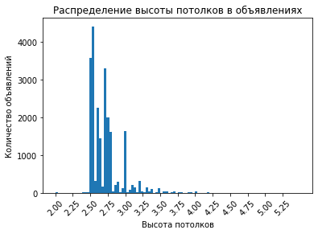

```python
data['ceiling_height'].plot.hist(bins = 100)
plt.title('Распределение высоты потолков в объявлениях')
plt.xlabel("Высота потолков")
plt.ylabel("Количество объявлений")
plt.xticks(np.arange(2, data['ceiling_height'].max(), 0.25))
plt.xticks(rotation = 45)
plt.show()
```

```python
print('Описательная статистика по столбцу ceiling_height')
data['ceiling_height'].describe()
```

```
Описательная статистика по столбцу ceiling_height
```

```
count    23011.000000
mean         2.704111
std          0.226715
min          2.000000
25%          2.550000
50%          2.650000
75%          2.750000
max          5.500000
Name: ceiling_height, dtype: float64
```

Высота потолков в объвлениях составляет от 2 до 5.5 метров. Медианное значение - 2.65 м., а среднее - 2.70 м.

### Изучите время продажи квартиры, постройте гистограмму. Посчитайте среднее и медиану. Опишите, сколько обычно занимает продажа. Когда можно считать, что продажи прошли очень быстро, а когда необычно долго?

Построим гистограмму и оценим время продажи квартиры.

```
Среднее время продажи квартиры: 156 дней.
Медианое время продажи квартиры: 73 дня.
```

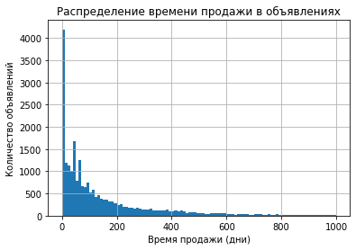

```python
data['days_exposition'].hist(bins=100, range= (0, 1000))
plt.title('Распределение времени продажи в объявлениях')
plt.xlabel("Время продажи (дни)")
plt.ylabel("Количество объявлений")
print(f'Среднее время продажи квартиры: {round(data["days_exposition"].mean())} дней.')
print(f'Медианое время продажи квартиры: {round(data["days_exposition"].median())} дня.')
```

**Вывод**

Можно считать, что квартира продавалась очень долго, если объявление снято более чем через 156 дней.